# Creating a Database of Amphibian Dermal Exposure Data and Assessing Model Performance

Purucker ST, Snyder MN, Glinski DA, Van Meter RJ, Garber K, Cyterski MJ, Sinnathamby S, Henderson WM

# **Introduction**

The purpose of this script is to combine the data sets from Van Meter et al. (2014, 2015, 2016, 2018), Glinski et al. (2018a, b, 2019, 2020), and Henson-Ramsey (2008) to create a collated database of amphibian dermal exposure data.

| Manuscript | Data Set (Original Source Link) | Data Set (Repo Link) | Additional Data Sets |
| --- | --- | --- | --- |
| [Van Meter et al. 2014](https://www.sciencedirect.com/science/article/pii/S0269749114002899?via%3Dihub) | [good_data.csv](https://github.com/puruckertom/VanMeteretal2014_EnvPoll/tree/master/data_in) | vm2014_data.csv |  |
| [Van Meter et al. 2015](https://link.springer.com/article/10.1007%2Fs00244-015-0183-2) | [good_data.csv](https://github.com/puruckertom/VanMeteretal2015_AECT/tree/master/data) | vm2014_data.csv |  |
| [Van Meter et al. 2016](https://setac.onlinelibrary.wiley.com/doi/full/10.1002/etc.3439) | [RDATA.csv](https://github.com/puruckertom/vanmeteretal2016_etc_amphibian_exposure_som/tree/master/data_in) | vm2016_data.csv |  |
| [Van Meter et al. 2018](https://www.sciencedirect.com/science/article/pii/S004896971733601X?via%3Dihub) | vm2017_merge.csv | vm2017_merge.csv |  |
| [Glinski et al. 2018a (dehydration)](https://link.springer.com/article/10.1007%2Fs11356-018-1830-8) | [dehydration3.csv](https://github.com/puruckertom/glinski_dehydration/tree/master/csv_in) | dag2016_data_dehydration.csv |  |
| [Glinski et al. 2018b (metabolites)](https://www.sciencedirect.com/science/article/pii/S0378427418300626?via%3Dihub) | [exposure_experiment.csv](https://github.com/puruckertom/glinski_metabolites/tree/master/csv_in) | dag2016_data_metabolites_4merge.csv |  |
| [Glinski et al. 2019 (biomarkers)](http://www.publish.csiro.au/en/EN18163) | [exposure_mixtures3.csv](https://github.com/puruckertom/glinski_biomarkers/tree/master/csv_in) | dag2018_data_biomarkers.csv | [biomarker.csv](https://github.com/puruckertom/glinski_biomarkers/tree/master/csv_in) (dag_biomarker2.csv) |
| Glinski et al. 2020 (dermal routes) | [Water_soil.csv](https://github.com/puruckertom/glinski_dermal_routes/tree/master/inputs) | dag2019_dermal_routes.csv | Dermal_routes_weights.csv (weights) |
| [Henson-Ramsey 2008](https://link.springer.com/article/10.1007/s00244-007-9091-4) | HensonRamseyetal2008_data.pdf | hr2008_data.csv |  |

# **Computational environment**

This repository can be found at: https://github.com/puruckertom/amphib_dermal_collation

If you are on a Mac and get xquartz complaints (knitr), install from: https://www.xquartz.org/

# **Data from Relevant Studies**

### Van Meter et al. 2014 and Van Meter et al. 2015

Van Meter et al. 2014 performed exposures for 5 pesticide active ingredients (imidacloprid, pendimethalin, atrazine, fipronil, tridimefon) and 7 species (Southern leopard frog (*Lithobates sphenocephala*), Fowler’s toad (*Anaxyrus fowleri*), gray treefrog (*Hyla versicolor*), Northern cricket frog (*Acris crepitans*), Eastern narrowmouth toad (*Gastrophryne carolinensis*), barking treefrog (*Hyla gratiosa*) and green treefrog (*Hyla cinerea*)). Whole body tissue concentrations were measured after an 8 hour exposure period to contaminated soil. Pesticides were applied at the maximum legally allowable application rates scaled down to the area of a 10-gallon aquarium (1225 cm<sup>2</sup>).

Van Meter et al. 2015 contrasted two pesticide exposure scenarios: direct exposure through aerial overspray and indirect exposure through soil. These scenarios tested the same 5 pesticide active ingredients and two of the species (barking treefrog (*Hyla gratiosa*) and green treefrog (*Hyla cinerea*)). Pesticides were applied at the maxium legally allowable application rates scaled down to the size of a 10-gallon aquarium, with the exception of pedimethalin which was applied at 30% of the permitted application rate. This was due to pedimethalin’s insolubility in the limited solvent and the water volumes used in this study.

For our purposes, the Van Meter et al. 2015 essentially adds the aerial overspray exposures to the Van Meter et al. 2014 data set.

*Note: this file does include metabolites into the total for the parents*

**Data Set Dimensions, Column Names, and Summary:**

```
## [1] 474  23
```

```
##  [1] "Species"        "Sample"         "Chemical"       "Instrument"
##  [5] "good"           "Application"    "app_rate_g_cm2" "TissueConc"
##  [9] "SoilConc"       "logKow"         "BCF"            "bodyweight"
## [13] "initialweight"  "Solat20C_mgL"   "Solat20C_gL"    "molmass_gmol"
## [17] "Density_gcm3"   "AppFactor"      "SA_cm2"         "VapPrs_mPa"
## [21] "Koc_gmL"        "HalfLife_day"   "HabFac"
```

```
##              Species        Sample                 Chemical   Instrument
##  Barking treefrog:120   FTA1   :  4   Total Triadimefon: 49   GCMS: 25
##  Green treefrog  :115   FTA2   :  4   Triadimefon      : 49   LCMS:449
##  Gray treefrog   : 60   FTA3   :  4   Triadimenol      : 49
##  Fowlers toad    : 55   FTA4   :  4   Atrazine         : 39
##  Leopard frog    : 44   FTA5   :  4   Fipronil         : 39
##  Mole salamander : 40   HCA1   :  4   Pendimethalin    : 39
##  (Other)         : 40   (Other):450   (Other)          :210
##       good      Application  app_rate_g_cm2    TissueConc
##  Min.   :1   Overspray:115   Min.   :0e+00   Min.   : 0.007484
##  1st Qu.:1   Soil     :359   1st Qu.:0e+00   1st Qu.: 0.246753
##  Median :1                   Median :0e+00   Median : 0.575811
##  Mean   :1                   Mean   :1e-05   Mean   : 1.908242
##  3rd Qu.:1                   3rd Qu.:2e-05   3rd Qu.: 1.743142
##  Max.   :1                   Max.   :2e-05   Max.   :23.441298
##                              NA's   :151
##     SoilConc            logKow           BCF             bodyweight
##  Min.   : 0.00625   Min.   :0.570   Min.   :  0.0018   Min.   :0.5004
##  1st Qu.: 0.20866   1st Qu.:2.500   1st Qu.:  0.0755   1st Qu.:1.3162
##  Median : 3.49248   Median :3.110   Median :  0.2069   Median :1.8550
##  Mean   : 7.22468   Mean   :3.142   Mean   : 11.3804   Mean   :1.8658
##  3rd Qu.:10.06719   3rd Qu.:4.000   3rd Qu.:  1.0828   3rd Qu.:2.3489
##  Max.   :81.71115   Max.   :5.180   Max.   :396.8461   Max.   :3.9931
##
##  initialweight     Solat20C_mgL     Solat20C_gL       molmass_gmol
##  Min.   :0.5004   Min.   :  0.30   Min.   :0.00030   Min.   :215.7
##  1st Qu.:1.6614   1st Qu.:  3.78   1st Qu.:0.00378   1st Qu.:215.7
##  Median :2.1766   Median : 30.00   Median :0.03000   Median :291.7
##  Mean   :2.2307   Mean   :123.20   Mean   :0.12320   Mean   :299.5
##  3rd Qu.:2.7601   3rd Qu.:260.00   3rd Qu.:0.26000   3rd Qu.:291.7
##  Max.   :5.5480   Max.   :510.00   Max.   :0.51000   Max.   :437.1
##
##   Density_gcm3     AppFactor           SA_cm2          VapPrs_mPa
##  Min.   :1.170   Min.   :    850   Min.   : 0.7915   Min.   :0.00020
##  1st Qu.:1.187   1st Qu.:  47011   1st Qu.: 1.5393   1st Qu.:0.00037
##  Median :1.220   Median : 143055   Median : 1.7866   Median :0.02000
##  Mean   :1.288   Mean   : 291904   Mean   : 3.0232   Mean   :0.34774
##  3rd Qu.:1.480   3rd Qu.: 348598   3rd Qu.: 2.0882   3rd Qu.:0.04000
##  Max.   :1.543   Max.   :4490329   Max.   :23.3326   Max.   :4.00000
##                  NA's   :151
##     Koc_gmL        HalfLife_day            HabFac
##  Min.   :   122   Min.   : 26.00   Aquatic    : 59
##  1st Qu.:   122   1st Qu.: 26.00   Arboreal   :300
##  Median :   520   Median : 80.00   Terrestrial:115
##  Mean   : 20406   Mean   : 70.85
##  3rd Qu.:   825   3rd Qu.: 84.00
##  Max.   :243000   Max.   :125.00
##
```

### Van Meter et al. 2016

Van Meter et al. 2016 considered bioconcentration of 5 current-use pesticides (imidacloprid, atrazine, triadimefon, fipronil, and pedimethalin) in American toads (*Bufo americanus*) across soil types. Toads were exposed to one of two soil types with significantly different organic matter content (14.1% = high organic matter, 3.1% = low organic matter). Whole body tissue concentrations were measured after an 8 hour exposure period to contaminated soil. Pesticides were applied at the maximum legally allowable application rates scaled down to the area of six 0.94 L Pyrex glass bowls each with a 15 cm diameter.

*Note: this file does include metabolites into the total for the parents*

**Data Set Dimensions, Column Names, and Summary:**

```
## [1] 264  11
```

```
##  [1] "Day"         "Row"         "Column"      "Pesticide"   "SoilType"
##  [6] "BodyBurden"  "Soil"        "Weight"      "Total"       "Formulation"
## [11] "Parent"
```

```
##       Day             Row            Column     Pesticide   SoilType
##  Min.   :0.000   Min.   :1.000   I      :37   ATZ    : 24   OLS:132
##  1st Qu.:2.000   1st Qu.:2.000   B      :35   ATZTOT : 24   PLE:132
##  Median :2.000   Median :4.000   A      :34   Pendi  : 24
##  Mean   :2.326   Mean   :4.023   C      :30   TDN    : 24
##  3rd Qu.:3.000   3rd Qu.:6.000   G      :30   TNDTOT : 24
##  Max.   :3.000   Max.   :7.000   D      :29   ATZDEA : 12
##                                  (Other):69   (Other):132
##    BodyBurden           Soil              Weight           Total
##  Min.   :-0.0378   Min.   :-0.10518   Min.   : 6.964   Min.   :0.0000
##  1st Qu.: 0.0486   1st Qu.: 0.02086   1st Qu.:10.524   1st Qu.:0.0000
##  Median : 0.1099   Median : 1.49572   Median :11.740   Median :0.0000
##  Mean   : 0.4955   Mean   : 6.02720   Mean   :12.044   Mean   :0.3636
##  3rd Qu.: 0.3650   3rd Qu.: 8.64289   3rd Qu.:13.440   3rd Qu.:1.0000
##  Max.   : 6.8744   Max.   :39.57404   Max.   :23.340   Max.   :1.0000
##
##   Formulation         Parent
##  Min.   :0.0000   Min.   :0.0000
##  1st Qu.:0.0000   1st Qu.:0.0000
##  Median :0.0000   Median :1.0000
##  Mean   :0.4091   Mean   :0.5909
##  3rd Qu.:1.0000   3rd Qu.:1.0000
##  Max.   :1.0000   Max.   :1.0000
##
```

### Glinski et al. 2018a (Dehydration)

Glinski et al. 2018a studied how amphibian hydration status influences uptake of pesticides through dermal exposure. Amphibians (Southern leopard frogs (*Lithobates sphenocephala*) and Fowler’s toads (*Anaxyrus fowleri*)) were dehyrated for periods of 0, 2, 4, 6, 8, or 10 hours prior to exposure to pesticide-contaminated soils. Pesticides studied included atrazine, triadimefon, metolachlor, chlorothalonil, and imidacloprid. Soil and whole-body homogenates were measured after an 8 hour exposure period. Pesticides were applied at the maximum legally allowable application rates scaled down to the area of six 0.94 L Pyrex glass bowls each with a 15 cm diameter.

*Note: this file does not combine daughters with parents*  
*Note: this file has body burdens and soil concentrations as separate rows*

**Data Set Dimensions, column Names, and Summary:**

```
## [1] 1494    8
```

```
## [1] "time"    "parent"  "analyte" "matrix"  "species" "conc"    "ID"
## [8] "weight"
```

```
##       time         parent        analyte       matrix    species
##  Min.   : 0   atrazine:396   atrazine:132   amphib:732   BA:630
##  1st Qu.: 2   chloro  :168   dea     :132   soil  :762   LF:864
##  Median : 5   chloro+d: 66   dia     :132
##  Mean   : 5   imid    : 72   mesa    :132
##  3rd Qu.: 8   metol   :396   metol   :132
##  Max.   :10   tdn     :396   moxa    :132
##                              (Other) :702
##       conc                 ID           weight
##  Min.   :  0.00000   BAA0-1 :   6   Min.   :0.6821
##  1st Qu.:  0.02215   BAA0-2 :   6   1st Qu.:1.6108
##  Median :  0.08482   BAA0-3 :   6   Median :3.0890
##  Mean   :  6.17646   BAA0-4 :   6   Mean   :3.0810
##  3rd Qu.:  2.60007   BAA0-5 :   6   3rd Qu.:4.3124
##  Max.   :238.15019   BAA10-1:   6   Max.   :7.2481
##                      (Other):1458
```

### Henson-Ramsey 2008

Henson-Ramsey 2008 tested the biological impact of exposure to malathion for tiger salamanders (*Ambystoma tigrinum*). Tiger salamanders were exposed to contaminated soils with 50 ug/cm<sup>2</sup> or 100 ug/cm<sup>2</sup> malathion and through ingestion of an earthworm exposed to contaminated soils with 200 ug/cm<sup>2</sup> malathion. For each exposure, the malathion application rate was sprayed onto the approximately 1200g of soil in the 1060cm<sup>2</sup> polyethylene cages. Tissue concentrations were assessed for five treatment groups: unexposed, exposed to 50 ug/cm<sup>2</sup> contaminated soil for 1 day, exposed to 50 ug/cm<sup>2</sup> for 2 days, exposed to 50 ug/cm<sup>2</sup> contaminated soil for 2 days and fed a contaminated worm on the first exposure day, and exposed to 100 ug/cm<sup>2</sup> contaminated soil for 2 days and fed a contaminated worm on the first exposure day.

**Data Set Dimensions, Column Names, and Summary:**

```
## [1]  9 12
```

```
##  [1] "chemical"        "species"         "tissue_conc_ugg" "sample_id"
##  [5] "body_weight_g"   "formulation"     "soil_type"       "application"
##  [9] "app_rate_g_cm2"  "exp_duration"    "soil_conc_ugg"   "source"
```

```
##       chemical               species  tissue_conc_ugg   sample_id
##  Malathion:9   Ambystoma_tigrinum:9   Min.   :0.050   sal1   :1
##                                       1st Qu.:0.350   sal2   :1
##                                       Median :1.420   sal3   :1
##                                       Mean   :1.186   sal4   :1
##                                       3rd Qu.:1.470   sal5   :1
##                                       Max.   :3.730   sal6   :1
##                                                       (Other):3
##  body_weight_g   formulation    soil_type      application app_rate_g_cm2
##  Min.   :20.89   Mode:logical   Mode:logical   soil:9      Min.   :5e-05
##  1st Qu.:44.15   NA's:9         NA's:9                     1st Qu.:5e-05
##  Median :46.26                                             Median :5e-05
##  Mean   :43.73                                             Mean   :5e-05
##  3rd Qu.:48.93                                             3rd Qu.:5e-05
##  Max.   :50.92                                             Max.   :5e-05
##
##   exp_duration soil_conc_ugg     source
##  Min.   :24    Mode:logical   hr2008:9
##  1st Qu.:24    NA's:9
##  Median :48
##  Mean   :40
##  3rd Qu.:48
##  Max.   :48
##
```

### Glinski et al. 2018b (Metabolites)

#### **Metabolites Data Set (1)**

**Data Set Dimensions, Column Names, and Summary:**

```
## [1] 352   6
```

```
## [1] "time"      "parent"    "analyte"   "matrix"    "conc"      "replicate"
```

```
##       time               parent          analyte      matrix
##  Min.   : 0.00   atrazine   :132   ATZ       :44   amphib:160
##  1st Qu.: 2.00   fipronil   : 88   DEA       :44   soil  :192
##  Median :12.00   triadimefon:132   DIA       :44
##  Mean   :16.41                     F. sulfone:44
##  3rd Qu.:24.00                     FIP       :44
##  Max.   :48.00                     TDL A     :44
##                                    (Other)   :88
##       conc            replicate
##  Min.   :-0.01244   Min.   :1.00
##  1st Qu.: 0.01292   1st Qu.:1.75
##  Median : 0.08373   Median :2.50
##  Mean   : 2.12963   Mean   :2.50
##  3rd Qu.: 0.97824   3rd Qu.:3.25
##  Max.   :32.47385   Max.   :4.00
##
```

#### **Metabolites Data Set (merged)**

**Data Set Dimensions, Column Names, and Summary:**

```
## [1] 60 12
```

```
##  [1] "exp_duration"    "chemical"        "tissue_conc_ugg" "sample_id"
##  [5] "soil_type"       "app_rate_g_cm2"  "soil_conc_ugg"   "body_weight_g"
##  [9] "formulation"     "species"         "application"     "source"
```

```
##   exp_duration        chemical  tissue_conc_ugg             sample_id
##  Min.   : 2    atrazine   :20   Min.   :0.08328   atrazine_12hr_1: 1
##  1st Qu.: 4    fipronil   :20   1st Qu.:0.33733   atrazine_12hr_2: 1
##  Median :12    triadimefon:20   Median :0.86010   atrazine_12hr_3: 1
##  Mean   :18                     Mean   :1.42634   atrazine_12hr_4: 1
##  3rd Qu.:24                     3rd Qu.:1.88383   atrazine_24hr_1: 1
##  Max.   :48                     Max.   :7.62649   atrazine_24hr_2: 1
##                                                   (Other)        :54
##  soil_type      app_rate_g_cm2      soil_conc_ugg  body_weight_g
##  Mode:logical   Min.   :1.100e-06   Mode:logical   Min.   :0.1879
##  NA's:60        1st Qu.:1.100e-06   NA's:60        1st Qu.:0.5925
##                 Median :2.700e-06                  Median :0.7144
##                 Mean   :9.237e-06                  Mean   :0.7350
##                 3rd Qu.:2.290e-05                  3rd Qu.:0.8782
##                 Max.   :2.290e-05                  Max.   :1.4909
##
##   formulation             species   application             source
##  Min.   :0    Anaxyrus_fowleri:60   soil:60     dag_metabolites:60
##  1st Qu.:0
##  Median :0
##  Mean   :0
##  3rd Qu.:0
##  Max.   :0
##
```

### Glinski et al. 2019 (Biomarkers)

Glinski et al. 2019 exposed Southern leopard frogs (*Lithobates sphenocephala*) to either the maximum or 1/10th maximum pesticide application rate to single, double, or triple pesticide mixtures of bifenthrin, metolachlor, and triadimefon to consider the typical co-application of pesticides during agricultural growing seasons. Tissue concentrations and metabolomic profiling of amphibian livers were studied after an 8 hour exposure period to pesticide-contaminated soil. Pesticides application rates were scaled down to the area of eight 0.94 L Pyrex glass bowls each with a 15 cm diameter.

**Data Set Dimensions, Column Names, and Summary:**

```
## [1] 192   9
```

```
## [1] "group"       "met"         "tdt"         "bif"         "frog.weight"
## [6] "sample_id"   "pesticide"   "rate"        "conc"
```

```
##        group         met               tdt               bif
##  bif      :16   Min.   :-1.0000   Min.   :-1.0000   Min.   :-1.0000
##  bifmet   :32   1st Qu.:-1.0000   1st Qu.:-1.0000   1st Qu.:-1.0000
##  bifmettdt:48   Median : 1.0000   Median : 1.0000   Median : 1.0000
##  biftdt   :32   Mean   : 0.3333   Mean   : 0.3333   Mean   : 0.3333
##  met      :16   3rd Qu.: 1.0000   3rd Qu.: 1.0000   3rd Qu.: 1.0000
##  mettdt   :32   Max.   : 1.0000   Max.   : 1.0000   Max.   : 1.0000
##  tdt      :16
##   frog.weight       sample_id   pesticide         rate         conc
##  Min.   :1.012   TMB 10 1:  3   bif:64    1/10th Max:96   Min.   : 0.001061
##  1st Qu.:2.745   TMB 10 2:  3   met:64    Maximum   :96   1st Qu.: 0.069055
##  Median :3.142   TMB 10 3:  3   tdt:64                    Median : 0.212920
##  Mean   :3.299   TMB 10 4:  3                             Mean   : 0.801643
##  3rd Qu.:3.789   TMB 10 5:  3                             3rd Qu.: 0.521471
##  Max.   :6.739   TMB 10 6:  3                             Max.   :19.879783
##                  (Other) :174
```

### Van Meter et al. 2018 (Multiple Pesticides Study)

Van Meter et al. 2018 evaluated risks to amphibians after exposure to a single pesticide and pesticide mixtures. The five pesticides studied were three herbicides (atrazine, metolachlor, and 2,4-D), one insecticide (malathion), and one fungicide (propiconazole). Juvenile green frogs (*Lithobates clamitans*) were exposed to contaminated soils for 8 hours and metabolic analysis of amphibian livers was conducted to measure the effects. Pesticides were applied at the maximum legally allowable application rates individually and in mixtures of two or three pesticides within an herbicide or mixed pesticide group, scaled down to the area of six 0.94 L Pyrex glass bowls each with a 15 cm diameter.

Two data sets were generated from this study, one containing data for exposure to herbicides (single and mixed) and the other containing data for exposure to mixed pesticide treatments (herbicides, insecticide, fungicide).

#### **Herbicide Data Set**

**Data Set Dimensions, Column Names, and Summary:**

```
## [1] 378  10
```

```
##  [1] "Group"     "ATZ"       "D"         "ME"        "AppRate"   "Weight"
##  [7] "SA"        "Media"     "Pesticide" "Conc"
```

```
##     Group         ATZ                D                 ME
##  ATZ   :54   Min.   :-1.0000   Min.   :-1.0000   Min.   :-1.0000
##  ATZD  :54   1st Qu.:-1.0000   1st Qu.:-1.0000   1st Qu.:-1.0000
##  ATZME :54   Median : 1.0000   Median : 1.0000   Median : 1.0000
##  ATZMED:54   Mean   : 0.1429   Mean   : 0.1429   Mean   : 0.1429
##  D     :54   3rd Qu.: 1.0000   3rd Qu.: 1.0000   3rd Qu.: 1.0000
##  ME    :54   Max.   : 1.0000   Max.   : 1.0000   Max.   : 1.0000
##  MED   :54
##     AppRate          Weight             SA           Media       Pesticide
##  Min.   :14.30   Min.   :0.9634   Min.   :1.107   Amphib:126   ATZBCF : 42
##  1st Qu.:23.60   1st Qu.:1.6929   1st Qu.:1.534   BCF   :126   ATZS   : 42
##  Median :37.90   Median :2.0637   Median :1.720   Soil  :126   ATZT   : 42
##  Mean   :39.31   Mean   :2.0892   Mean   :1.715                DBCF   : 42
##  3rd Qu.:54.50   3rd Qu.:2.4927   3rd Qu.:1.919                DS     : 42
##  Max.   :68.80   Max.   :3.6843   Max.   :2.406                DT     : 42
##                                                                (Other):126
##       Conc
##  Min.   : 0.00000
##  1st Qu.: 0.00000
##  Median : 0.06358
##  Mean   : 5.64721
##  3rd Qu.: 1.46036
##  Max.   :76.03573
##
```

#### **Mixed Pesticide Data Set**

**Data Set Dimensions, Column Names, and Summary:**

```
## [1] 216   9
```

```
## [1] "Group"     "ATZ"       "MA"        "PROP"      "Pesticide" "Media"
## [7] "Conc"      "Weight"    "SA"
```

```
##      Group         ATZ                MA               PROP
##  ATZ    :18   Min.   :-1.0000   Min.   :-1.0000   Min.   :-1.0000
##  ATZMA  :36   1st Qu.:-1.0000   1st Qu.:-1.0000   1st Qu.:-1.0000
##  ATZMAPZ:54   Median : 1.0000   Median : 1.0000   Median : 1.0000
##  ATZPZ  :36   Mean   : 0.3333   Mean   : 0.3333   Mean   : 0.3333
##  MA     :18   3rd Qu.: 1.0000   3rd Qu.: 1.0000   3rd Qu.: 1.0000
##  MAPZ   :36   Max.   : 1.0000   Max.   : 1.0000   Max.   : 1.0000
##  PZ     :18
##    Pesticide     Media         Conc              Weight            SA
##  ATZBCF :24   Amphib:72   Min.   : 0.00024   Min.   :1.188   Min.   :1.447
##  ATZS   :24   BCF   :72   1st Qu.: 0.32682   1st Qu.:1.786   1st Qu.:1.833
##  ATZT   :24   Soil  :72   Median : 1.61181   Median :2.014   Median :1.965
##  MABCF  :24               Mean   : 5.46049   Mean   :2.203   Mean   :2.047
##  MAS    :24               3rd Qu.: 9.99874   3rd Qu.:2.455   3rd Qu.:2.203
##  MAT    :24               Max.   :71.52122   Max.   :4.014   Max.   :2.929
##  (Other):72
```

The herbicide and mixed pesticide data sets were cleaned prior and joined into a merged data set (referred to as Van Meter et al. 2018 Multiple Pesticides Study in subsequent steps). The single and mixed-pesticide treatments that were retained in the merged data set include atrazine, propiconazole, 2,4-D, malathion, and metolachlor. Original columns from the herbicide and mixed pesticide data sets were altered for standardization. These standardized columns will be used in future data cleaning steps in order to merge all data sets.

#### **Merged Data Set**

**Data Set Dimensions, Column Names, and Summary:**

```
## [1] 137  12
```

```
##  [1] "app_rate_g_cm2"  "body_weight_g"   "chemical"        "tissue_conc_ugg"
##  [5] "sample_id"       "source"          "application"     "exp_duration"
##  [9] "formulation"     "soil_conc_ugg"   "soil_type"       "species"
```

```
##  app_rate_g_cm2      body_weight_g     chemical  tissue_conc_ugg
##  Min.   :2.600e-06   Min.   :0.9634   ATZT :42   Min.   : 0.00054
##  1st Qu.:1.430e-05   1st Qu.:1.7623   DT   :23   1st Qu.: 0.27576
##  Median :2.360e-05   Median :2.0136   MAT  :24   Median : 1.41009
##  Mean   :2.004e-05   Mean   :2.1086   MET  :24   Mean   : 7.36154
##  3rd Qu.:2.590e-05   3rd Qu.:2.3395   PROPT:24   3rd Qu.: 9.95084
##  Max.   :3.090e-05   Max.   :4.0141              Max.   :72.62672
##
##         sample_id       source    application  exp_duration  formulation
##  ATZ_ATZT    :  6   rvm2017:137   soil:137    Min.   :8     Min.   :0
##  ATZD_ATZT   :  6                             1st Qu.:8     1st Qu.:0
##  ATZMA_ATZT  :  6                             Median :8     Median :0
##  ATZMA_MAT   :  6                             Mean   :8     Mean   :0
##  ATZMAPZ_ATZT:  6                             3rd Qu.:8     3rd Qu.:0
##  ATZMAPZ_MAT :  6                             Max.   :8     Max.   :0
##  (Other)     :101
##  soil_conc_ugg  soil_type                species
##  Mode:logical   Mode:logical   Rana_clamitans:137
##  NA's:137       NA's:137
##
##
##
##
##
```

### Glinski et al. 2020 (Dermal Routes)

Glinski et al. 2020 assessed dermal uptake in amphibians from exposure to three pesticides (bifenthrin, chlorpyrifos, trifloxystrobin). Pesiticide body burdens and hepatic metabolome for Leopard frogs were measured for two routes of uptake: uptake from contaminated soils versus uptake from contaminated surface water. Pesticides were applied at 1 ppm, scaled down to the area of eight 0.94 L Pyrex glass bowls each with a 15 cm diameter.

**Data Set Dimensions, Column Names, and Summary:**

```
## [1] 192   5
```

```
## [1] "Sample.ID"     "Analyte"       "Media"         "Matrix"
## [5] "Concentration"
```

```
##         Sample.ID   Analyte     Media          Matrix   Concentration
##  Bif LF S 1 F:  2   4-OH:32   Soil :96   Amphibian:96   Min.   :0.00000
##  Bif LF S 1 S:  2   BIF :32   Water:96   Soil     :48   1st Qu.:0.01036
##  Bif LF S 2 F:  2   CPF :32              Water    :48   Median :0.15326
##  Bif LF S 2 S:  2   CPO :32                             Mean   :0.33962
##  Bif LF S 3 F:  2   TFS :32                             3rd Qu.:0.44162
##  Bif LF S 3 S:  2   TFSa:32                             Max.   :3.40759
##  (Other)     :180
```

# **Application Rates**

The table below concisely displays the pesticide applications rates (ug/cm<sup>2</sup>) used in each relevant study as well as the variables used to compute the application rates.

| pesticide | app_rate_ug_cm2 | applied_mL | container | area_cm2 | total_area_cm2 | density_g_cm3 | pesticide_mg |
| --- | --- | --- | --- | --- | --- | --- | --- |
| **Van Meter et al. 2014/2015** |  |  |  |  |  |  |  |
| atrazine | 22.9000 | 75 MeOH | 10-gal aquarium | 1225 | 1225 | 1.1900 | 28.9 |
| fipronil | 1.1000 | 75 MeOH | 10-gal aquarium | 1225 | 1225 | 1.5515 | 1.4 |
| imidacloprid | 5.7000 | 75 MeOH | 10-gal aquarium | 1225 | 1225 | 1.6000 | 7.11 |
| pendimethalin | 19.8000 | 75 MeOH | 10-gal aquarium | 1225 | 1225 | 1.1700 | 25 |
| triadimefon | 2.7000 | 75 MeOH | 10-gal aquarium | 1225 | 1225 | 1.2200 | 3.5 |
| **Van Meter et al. 2016** |  |  |  |  |  |  |  |
| atrazine | 22.9000 | 75 MeOH | .94 L bowl | 225*6 | 1350 | 1.1900 | ?? |
| fipronil | 1.1000 | 75 MeOH | .94 L bowl | 225*6 | 1350 | 1.5515 | ?? |
| imidacloprid | 5.7000 | 75 MeOH | .94 L bowl | 225*6 | 1350 | 1.6000 | ?? |
| pendimethalin | 69.8000 | 75 MeOH | .94 L bowl | 225*6 | 1350 | 1.1700 | ?? |
| triadimefon | 2.7000 | 75 MeOH | .94 L bowl | 225*6 | 1350 | 1.2200 | ?? |
| **Van Meter et al. 2018** |  |  |  |  |  |  |  |
| atrazine | 23.6000 | 50 MeOH | .94 L bowl | 225*6 | 1350 | 1.1900 | ?? |
| 2,4-D | 14.3000 | 50 MeOH | .94 L bowl | 225*6 | 1350 | 1.5000 | ?? |
| metolachlor | 30.9000 | 50 MeOH | .94 L bowl | 225*6 | 1350 | 1.1000 | ?? |
| malathion | 25.9000 | 50 MeOH | .94 L bowl | 225*6 | 1350 | 1.2300 | ?? |
| propiconazole | 2.6000 | 50 MeOH | .94 L bowl | 225*6 | 1350 | 1.3000 | ?? |
| **Henson-Ramsey et al. 2008** |  |  |  |  |  |  |  |
| malathion | 50.0000 | NA | cage | 1060 | NA | 1.2300 | ?? |
| **Glinski et al. 2018a** |  |  |  |  |  |  |  |
| atrazine | 23.9500 | 75 MeOH | .94 L bowl | 225*6 | 1350 | 1.1900 | 32.33 |
| chlorothalonil | 44.3000 | 75 MeOH | .94 L bowl | 225*6 | 1350 | 1.8000 | 59.79 |
| imidacloprid | 5.3900 | 75 MeOH | .94 L bowl | 225*6 | 1350 | 1.6000 | 7.2 |
| metolachlor | 31.0100 | 75 MeOH | .94 L bowl | 225*6 | 1350 | 1.1000 | 41.85 |
| triadimefon | 2.9100 | 75 MeOH | .94 L bowl | 225*6 | 1350 | 1.2200 | 3.97 |
| **Glinski et al. 2018b** |  |  |  |  |  |  |  |
| atrazine | 22.9000 | 75 MeOH | 10-gal aquarium | 1225 | 1225 | 1.1900 | 28.89 |
| fipronil | 1.1000 | 75 MeOH | 10-gal aquarium | 1225 | 1225 | 1.5515 | 1.41 |
| triadimefon | 2.7000 | 75 MeOH | 10-gal aquarium | 1225 | 1225 | 1.2200 | 3.53 |
| **Glinski et al. 2019** |  |  |  |  |  |  |  |
| bifenthrin (max) | 3.4500 | 75 MeOH | .94 L bowl | 225*8 | 1800 | 1.3000 | 6.2 |
| metolachlor (max) | 30.6200 | 75 MeOH | .94 L bowl | 225*8 | 1800 | 1.1000 | 55.43 |
| triadimefon (max) | 2.8700 | 75 MeOH | .94 L bowl | 225*8 | 1800 | 1.2200 | 5.16 |
| bifenthrin (1/10 max) | 0.3450 | 75 MeOH | .94 L bowl | 225*8 | 1800 | 1.3000 | 0.65 |
| metolachlor (1/10 max) | 3.0620 | 75 MeOH | .94 L bowl | 225*8 | 1800 | 1.1000 | 5.46 |
| triadimefon (1/10 max) | 0.2870 | 75 MeOH | .94 L bowl | 225*8 | 1800 | 1.2200 | 0.52 |
| **Glinski et al. 2020** |  |  |  |  |  |  |  |
| bifenthrin | 0.2889 | 400ml of 1ppm pesticide in water | .94 L bowl | 225*8 | 1800 | 1.3000 | 50ml/bowl |
| chlorpyrifos | 0.3111 | 400ml of 1ppm pesticide in water | .94 L bowl | 225*8 | 1800 | 1.4000 | 50ml/bowl |
| trifloxystrobin | 0.3022 | 400ml of 1ppm pesticide in water | .94 L bowl | 225*8 | 1800 | 1.3600 | 50ml/bowl |

# **Cleaning and Merging the Data Sets**

Each data set was cleaned for merging. This consisted of dropping unneeded columns and standardizing column names of retained columns. Four columns were added to all data sets (soil type, formulation, exposure duration, and research study source).  
Once each data set was cleaned, a local copy was saved and the data set was merged with the previously cleaned data sets.

The process of cleaning and merging each data set is briefly described below.

### Van Meter et al. 2014/2015

Metabolites and parents that do not include metabolites were dropped from the data set. This includes atrazine, deisopropyl atrazine, desethyl atrazine, fipronil, fipronil-sulfone, triadimefon, triadimenol.

```r
# drop metabolites and parents that do not include metabolites
vm2015_chem_drop <- c("Atrazine","Deisopropyl Atrazine","Desethyl Atrazine","Fipronil","Fipronil-Sulfone","Triadimefon","Triadimenol")
chem_vector_drop <- which(vm2015$Chemical %in% vm2015_chem_drop)
vm2015_subset1 <- vm2015[-chem_vector_drop,]
vm2015_subset2 <- droplevels(vm2015_subset1)
```

There were 278 observations with these chemicals. After dropping the 278 observations from the initial 474, the updated dimensions are:

```
## [1] 196  23
```

There were 15 unneeded columns dropped and 4 added for standarization.

```r
# drop unneeded columns for merging
all_cols <- colnames(vm2015_subset2)
drop_cols <- c("Instrument", "good", "logKow", "BCF", "initialweight",
            "Solat20C_mgL", "Solat20C_gL", "molmass_gmol", "Density_gcm3","AppFactor", "SA_cm2", "VapPrs_mPa",
            "Koc_gmL", "HalfLife_day", "HabFac")
vm2015_subset3 <- vm2015_subset2[,!(names(vm2015_subset2) %in% drop_cols)]
colnames(vm2015_subset3)
```

```
## [1] "Species"        "Sample"         "Chemical"       "Application"
## [5] "app_rate_g_cm2" "TissueConc"     "SoilConc"       "bodyweight"
```

```r
# add columns
soil_type <- c(rep("PLE",nrow(vm2015_subset3)))
formulation <- (rep(0,nrow(vm2015_subset3)))
exp_duration<- (rep(8,nrow(vm2015_subset3)))
source <- c(rep("rvm2015",nrow(vm2015_subset3)))
vm2015_subset4 <- cbind(vm2015_subset3, formulation, soil_type, exp_duration, source)
# standardize column names
colnames(vm2015_subset4)
```

```
##  [1] "Species"        "Sample"         "Chemical"       "Application"
##  [5] "app_rate_g_cm2" "TissueConc"     "SoilConc"       "bodyweight"
##  [9] "formulation"    "soil_type"      "exp_duration"   "source"
```

```r
colnames(vm2015_subset4)[which(colnames(vm2015_subset4)=="Sample")]<-"sample_id"
colnames(vm2015_subset4)[which(colnames(vm2015_subset4)=="Species")]<-"species"
colnames(vm2015_subset4)[which(colnames(vm2015_subset4)=="Chemical")]<-"chemical"
colnames(vm2015_subset4)[which(colnames(vm2015_subset4)=="Application")]<-"application"
colnames(vm2015_subset4)[which(colnames(vm2015_subset4)=="TissueConc")]<-"tissue_conc_ugg"
colnames(vm2015_subset4)[which(colnames(vm2015_subset4)=="SoilConc")]<-"soil_conc_ugg"
colnames(vm2015_subset4)[which(colnames(vm2015_subset4)=="bodyweight")]<-"body_weight_g"
colnames(vm2015_subset4)
```

```
##  [1] "species"         "sample_id"       "chemical"        "application"
##  [5] "app_rate_g_cm2"  "tissue_conc_ugg" "soil_conc_ugg"   "body_weight_g"
##  [9] "formulation"     "soil_type"       "exp_duration"    "source"
```

```r
# reorder vm2015 alphabetically
vm2015_merge <- vm2015_subset4[,order(names(vm2015_subset4))]

# write a local copy
vm2015_merge_filename <- paste(amphibdir_data_out,"vm2015_merge.csv", sep="")
write.csv(vm2015_merge, file=vm2015_merge_filename)
```

**The data set’s dimensions are:**

```
## [1] 196  12
```

### Van Meter et al. 2016

From the initial 11 columns, 4 columns were dropped and consolidated into 1, and 4 columns were added.

```r
# add sample_id
vm2016$sample_id <- paste(vm2016$Day, vm2016$Row, vm2016$Column, sep="_")
vm2016_subset2 <- subset(vm2016, select=c(-Day,-Row, -Column, -Total))
# add additional columns
species <- c(rep("American toad",nrow(vm2016_subset2)))
application <- c(rep("Indirect",nrow(vm2016_subset2)))
exp_duration<- (rep(8,nrow(vm2016_subset2)))
source <- c(rep("rvm2016",nrow(vm2016_subset2)))
vm2016_subset3 <- cbind(vm2016_subset2, species, application, exp_duration, source)
```

Application rates for several pesticides were inserted. There were 108 observations with decay products that were not sprayed; these observations were dropped so as to only include the parents in the cleaned data set. There were 60 observations with atrazine, fipronil, or triadimefon that were dropped because they do not include metabolites in total.

```r
# assign values to application rate
#unique(vm2016_subset3$Pesticide)
vm2016_subset3$app_rate_g_cm2[vm2016_subset3$Pesticide=="ATZTOT"] <- 22.9e-6
vm2016_subset3$app_rate_g_cm2[vm2016_subset3$Pesticide=="Imid"] <- 5.7e-6
vm2016_subset3$app_rate_g_cm2[vm2016_subset3$Pesticide=="FipTOT"] <- 1.1e-6
vm2016_subset3$app_rate_g_cm2[vm2016_subset3$Pesticide=="TNDTOT"] <- 2.7e-6
vm2016_subset3$app_rate_g_cm2[vm2016_subset3$Pesticide=="Pendi"] <- 69.8e-6
# drop decay products that were not sprayed, keeping only parents
rows_to_drop <- which(vm2016_subset3$Parent == 0)
vm2016_subset4 <- vm2016_subset3[-rows_to_drop,]
# drop ATZ, Fip, TDN since do not include metabolites in total
chems_to_drop <- c("ATZ","Fip","TDN")
vm2016_subset5 <- vm2016_subset4[!(vm2016_subset4$Pesticide %in% chems_to_drop),]
# drop parent field
drop_cols <- c("Parent")
vm2016_subset6 <- vm2016_subset5[,!(names(vm2016_subset5) %in% drop_cols)]
```

Several column names were standardized and all columns were ordered for ease of merging with the combined data set.

```r
# standardize column names
colnames(vm2016_subset6)
```

```
##  [1] "Pesticide"      "SoilType"       "BodyBurden"     "Soil"
##  [5] "Weight"         "Formulation"    "sample_id"      "species"
##  [9] "application"    "exp_duration"   "source"         "app_rate_g_cm2"
```

```r
colnames(vm2016_subset6)[which(colnames(vm2016_subset6)=="Pesticide")]<-"chemical"
colnames(vm2016_subset6)[which(colnames(vm2016_subset6)=="SoilType")]<-"soil_type"
colnames(vm2016_subset6)[which(colnames(vm2016_subset6)=="BodyBurden")]<-"tissue_conc_ugg"
colnames(vm2016_subset6)[which(colnames(vm2016_subset6)=="Soil")]<-"soil_conc_ugg"
colnames(vm2016_subset6)[which(colnames(vm2016_subset6)=="Weight")]<-"body_weight_g"
colnames(vm2016_subset6)[which(colnames(vm2016_subset6)=="Formulation")]<-"formulation"

# alter chemical name
vm2016_subset6$chemical <- as.character(vm2016_subset6$chemical)
vm2016_subset6$chemical[vm2016_subset6$chemical=="Imid"] <- "imidacloprid"

# reorder columns alphabetically to help with merge
colnames(vm2016_subset6)
```

```
##  [1] "chemical"        "soil_type"       "tissue_conc_ugg" "soil_conc_ugg"
##  [5] "body_weight_g"   "formulation"     "sample_id"       "species"
##  [9] "application"     "exp_duration"    "source"          "app_rate_g_cm2"
```

```r
vm2016_merge <- vm2016_subset6[,order(names(vm2016_subset6))]
colnames(vm2016_merge)
```

```
##  [1] "app_rate_g_cm2"  "application"     "body_weight_g"   "chemical"
##  [5] "exp_duration"    "formulation"     "sample_id"       "soil_conc_ugg"
##  [9] "soil_type"       "source"          "species"         "tissue_conc_ugg"
```

```r
# write a local copy
vm2016_merge_filename <- paste(amphibdir_data_out,"vm2016_merge.csv", sep="")
write.csv(vm2016_merge, file=vm2016_merge_filename)
```

The updated dimensions are:

```
## [1] 96 12
```

The Van Meter et al. 2014/2015 and Van Meter et al. 2016 data sets were combined.

**The combined data set’s updated dimensions are:**

```
## [1] 292  12
```

### Glinski et al. 2018a (Dehydration)

The metabolite products were dropped from the data set; 600 rows from the initial 1494 rows were retained.

```r
# drop metabolite products
parent_keepers <- which(as.vector(dag2016_dehy0$parent) == as.vector(dag2016_dehy0$analyte))
dag2016_dehy1 <- dag2016_dehy0[parent_keepers,]
```

Several column names were altered for standarization across the data set, and 7 columns were added for standarization.

```r
## time is length of dehydration
#colnames(dag2016_dehy1)[which(colnames(dag2016_dehy1)=="time")]<-"exp_duration"

# standardize column names
colnames(dag2016_dehy1)[which(colnames(dag2016_dehy1)=="analyte")]<-"chemical"
colnames(dag2016_dehy1)[which(colnames(dag2016_dehy1)=="conc")]<-"tissue_conc_ugg"
colnames(dag2016_dehy1)[which(colnames(dag2016_dehy1)=="ID")]<-"sample_id"
colnames(dag2016_dehy1)[which(colnames(dag2016_dehy1)=="weight")]<-"body_weight_g"

# add additional columns
exp_duration <- c(rep(8,nrow(dag2016_dehy1)))
soil_type <- c(rep("PLE",nrow(dag2016_dehy1)))
application <- c(rep("Indirect",nrow(dag2016_dehy1)))
formulation <- (rep(0,nrow(dag2016_dehy1)))
app_rate_g_cm2 <- (rep(0,nrow(dag2016_dehy1)))
soil_conc_ugg <- (rep(0,nrow(dag2016_dehy1)))
source <- c(rep("dag_dehydration",nrow(dag2016_dehy1)))
dag2016_dehy2 <- cbind(dag2016_dehy1, formulation, soil_type, application,
                       app_rate_g_cm2, exp_duration, soil_conc_ugg, source)
```

The updated dimensions are:

```
## [1] 600  15
```

Multiple soil concentration observations were given the same ID. Until a many-to-one merge of soil concentrations could be executed, 300 rows were temporarily dropped. There were also 3 columns dropped.

```r
# drop the soil until we can do a many-to-one merge of soil concentrations
# drop decay products that were not sprayed, keeping only parents
rows_to_drop <- which(dag2016_dehy2$matrix == 'soil')
dag2016_dehy3 <- dag2016_dehy2[-rows_to_drop,]
# parent, time and matrix columns delete
drop_cols <- c("parent","time","matrix")
dag2016_dehy4 <- dag2016_dehy3[,!(names(dag2016_dehy3) %in% drop_cols)]
```

The updated dimensions are:

```
## [1] 300  12
```

The application rate values were inserted, the temporarily dropped soil concentrations were updated to the current data set, and the species names were standardized.

```r
# fill in application rates
#unique(dag2016_dehy4$chemical)
update_atrazine <- which(dag2016_dehy4$chemical == 'atrazine')
dag2016_dehy4$app_rate_g_cm2[update_atrazine] <- 0.00002395 # atrazine g/cm2
update_chloro <- which(dag2016_dehy4$chemical == 'chloro+d')
dag2016_dehy4$app_rate_g_cm2[update_chloro] <-  0.0000443 # chloro g/cm2
update_metol <- which(dag2016_dehy4$chemical == 'metol')
dag2016_dehy4$app_rate_g_cm2[update_metol] <-  0.00003101 # metol g/cm2
update_tdn <- which(dag2016_dehy4$chemical == 'tdn')
dag2016_dehy4$app_rate_g_cm2[update_tdn] <- 0.00000291 # tdn g/cm2
update_imid <- which(dag2016_dehy4$chemical == 'imid')
dag2016_dehy4$app_rate_g_cm2[update_imid] <- 0.00000539 # imid g/cm2

# add back in soil concentrations (in already-made soil_conc_ugg column)
dag2016_soil <- dag2016_dehy2[rows_to_drop,]
dag2016_dehy4$soil_conc_ugg <- dag2016_soil$tissue_conc_ugg

# rename species names, according to standardized names
dag2016_dehy4$species <- as.character(dag2016_dehy4$species)
dag2016_dehy4$species[dag2016_dehy4$species == "LF"] <- "Leopard frog"
dag2016_dehy4$species[dag2016_dehy4$species == "BA"] <- "Fowlers toad"
dag2016_dehy4$species <- as.factor(dag2016_dehy4$species)
```

The dimensions are:

```
## [1] 300  12
```

The Glinkski et al. 2018a (Dehydration) was combined with the previously merged data sets.

**The combined data set’s updated dimensions are:**

```
## [1] 592  12
```

### Henson-Ramsey 2008

The Henson-Ramsey 2008 data set did not require any additional data cleaning. It was combined with the previously merged data sets.

**The combined data set’s updated dimensions are:**

```
## [1] 601  12
```

### Glinski et al. 2018b (Metabolites)

Apart from standardizing the species name, the Glinski et al. 2018b (Metabolites) data set did not require any additional data cleaning. It was combined with the previously merged data sets.

```r
# rename species names, according to standardized names
dag2016_metabolite_merge$species <- as.character(dag2016_metabolite_merge$species)
dag2016_metabolite_merge$species[dag2016_metabolite_merge$species == "Anaxyrus_fowleri"] <- "Fowlers toad"
dag2016_metabolite_merge$species <- as.factor(dag2016_metabolite_merge$species)
```

**The combined data set’s updated dimensions are:**

```
## [1] 661  12
```

### Glinski et al. 2019 (Biomarkers)

Five columns were dropped from the original biomarkers data set and the names of two columns were standardized.

```r
# drop columns
drop_cols <- c("met", "tdt", "bif", "rate", "group")
dag_biomarker_subset <- dag_biomarker[, !(names(dag_biomarker) %in% drop_cols)]

# standardize column names
colnames(dag_biomarker_subset)[which(colnames(dag_biomarker_subset)=="conc")]<-"tissue_conc_ugg"
colnames(dag_biomarker_subset)[which(colnames(dag_biomarker_subset)=="frog.weight")]<-"body_weight_g"
```

The updated column names and dimensions are:

```
## [1] "body_weight_g"   "sample_id"       "pesticide"       "tissue_conc_ugg"
```

```
## [1] 192   4
```

The application rates and soil concentrations were not included in the original biomarkers data set. Both are included in the following data set:

**Data Set Dimensions, Column Names, and Summary:**

```
## [1] 136  15
```

```
##  [1] "frog.weight"  "SAMPLE"       "Met"          "TDN"          "TDL"
##  [6] "BIF"          "soil.weight"  "Met.soil"     "TDN.soil"     "TDL.soil"
## [11] "BIF.soil"     "Rate"         "app.rate.met" "app.rate.tdn" "app.rate.bif"
```

```
##   frog.weight         SAMPLE         Met               TDN
##  Min.   :1.012   BIF 10 1:  1   Min.   : 0.0000   Min.   :0.00000
##  1st Qu.:2.749   BIF 10 2:  1   1st Qu.: 0.0000   1st Qu.:0.00000
##  Median :3.164   BIF 10 3:  1   Median : 0.0000   Median :0.00000
##  Mean   :3.302   BIF 10 4:  1   Mean   : 0.9123   Mean   :0.06927
##  3rd Qu.:3.762   BIF 10 5:  1   3rd Qu.: 0.4298   3rd Qu.:0.07447
##  Max.   :6.784   BIF 10 6:  1   Max.   :19.8798   Max.   :0.55921
##                  (Other) :130
##       TDL               BIF          soil.weight        Met.soil
##  Min.   :0.00000   Min.   :0.0000   Min.   : 4.476   Min.   :0.000
##  1st Qu.:0.00000   1st Qu.:0.0000   1st Qu.: 6.731   1st Qu.:0.000
##  Median :0.00000   Median :0.0000   Median : 7.772   Median :0.000
##  Mean   :0.02259   Mean   :0.1276   Mean   : 8.043   Mean   :1.605
##  3rd Qu.:0.01770   3rd Qu.:0.1299   3rd Qu.: 9.050   3rd Qu.:2.265
##  Max.   :0.30815   Max.   :1.0271   Max.   :13.571   Max.   :6.758
##
##     TDN.soil         TDL.soil           BIF.soil        Rate
##  Min.   :0.0000   Min.   :0.000000   Min.   :0.0000   0   :24
##  1st Qu.:0.0000   1st Qu.:0.000000   1st Qu.:0.0000   High:56
##  Median :0.0000   Median :0.000000   Median :0.0000   Low :56
##  Mean   :0.7168   Mean   :0.010160   Mean   :0.7417
##  3rd Qu.:0.5312   3rd Qu.:0.007463   3rd Qu.:1.1472
##  Max.   :3.6300   Max.   :0.061563   Max.   :5.2658
##
##   app.rate.met     app.rate.tdn     app.rate.bif
##  Min.   : 0.000   Min.   :0.0000   Min.   :0.0000
##  1st Qu.: 0.000   1st Qu.:0.0000   1st Qu.:0.0000
##  Median : 0.000   Median :0.0000   Median :0.0000
##  Mean   :14.263   Mean   :1.3389   Mean   :1.6070
##  3rd Qu.: 5.511   3rd Qu.:0.5173   3rd Qu.:0.6209
##  Max.   :55.106   Max.   :5.1730   Max.   :6.2090
##
```

The application rates were converted from mg to g/cm<sup>2</sup>.

```r
dag_biomarker2_update <- replace.value(dag_biomarker2, "app.rate.met", from=55.106, to=3.062e-5, verbose=TRUE)
dag_biomarker2_update <- replace.value(dag_biomarker2_update, "app.rate.met", from=5.5106, to=3.062e-6, verbose=FALSE)
dag_biomarker2_update <- replace.value(dag_biomarker2_update, "app.rate.tdn", from=5.173, to=2.87e-6, verbose=FALSE)
dag_biomarker2_update <- replace.value(dag_biomarker2_update, "app.rate.tdn", from=.5173, to=2.87e-7, verbose=FALSE)
dag_biomarker2_update <- replace.value(dag_biomarker2_update, "app.rate.bif", from=6.209, to=3.45e-6, verbose=FALSE)
dag_biomarker2_update <- replace.value(dag_biomarker2_update, "app.rate.bif", from=.6209, to=3.45e-7, verbose=FALSE)
```

A one-to-one merge was conducted based on the unique sample id for each measured pesticide (either bifenthrin, metolachlor, or triadimefon) to join the original biomarkers data set and the data set containing the application rates and soil concentrations. Vectors containing the application rates and soil concentrations were joined to the original data set.

```r
# bif extraction
dag_biomarker_subset_bif <- dag_biomarker_subset[dag_biomarker_subset$pesticide == "bif", ]
dag_biomarker2_subset_bif <- dag_biomarker2_update[dag_biomarker2_update$BIF != 0, ]

dag_biomarker_bif_merge <- merge(x = dag_biomarker_subset_bif, y = dag_biomarker2_subset_bif,
                                by.x = "sample_id", by.y = "SAMPLE", all.x = TRUE)

# met extraction
dag_biomarker_subset_met <- dag_biomarker_subset[dag_biomarker_subset$pesticide == "met", ]
dag_biomarker2_subset_met <- dag_biomarker2_update[dag_biomarker2_update$Met != 0, ]

dag_biomarker_met_merge <- merge(x = dag_biomarker_subset_met, y = dag_biomarker2_subset_met,
                                 by.x = "sample_id", by.y = "SAMPLE", all.x = TRUE)

# tdt extraction
dag_biomarker_subset_tdt <- dag_biomarker_subset[dag_biomarker_subset$pesticide == "tdt", ]
dag_biomarker2_subset_tdt <- dag_biomarker2_update[dag_biomarker2_update$TDN != 0, ]

dag_biomarker_tdt_merge <- merge(x = dag_biomarker_subset_tdt, y = dag_biomarker2_subset_tdt,
                                 by.x = "sample_id", by.y = "SAMPLE", all.x = TRUE)


# combine bif, met, and tdt
app_bind_bmt <- c(dag_biomarker_bif_merge[,"app.rate.bif"],
                  dag_biomarker_met_merge[,"app.rate.met"], dag_biomarker_tdt_merge[,"app.rate.tdn"])

soil_bind_bmt <- c(dag_biomarker_bif_merge[,"BIF.soil"],
                   dag_biomarker_met_merge[,"Met.soil"], dag_biomarker_tdt_merge[,"TDN.soil"])


# join app and soil vectors to data set
dag_biomarker_subset2 <- dag_biomarker_subset[order(dag_biomarker_subset[, 3]),]
rownames(dag_biomarker_subset2) <- seq(length=nrow(dag_biomarker_subset2))

dag_biomarker_subset3 <- cbind(dag_biomarker_subset2, app_bind_bmt, soil_bind_bmt)

# standardize column names
colnames(dag_biomarker_subset3)[which(colnames(dag_biomarker_subset3)=="app_bind_bmt")]<-"app_rate_g_cm2"
colnames(dag_biomarker_subset3)[which(colnames(dag_biomarker_subset3)=="soil_bind_bmt")]<-"soil_conc_ugg"
```

The updated column names and dimensions are:

```
## [1] "body_weight_g"   "sample_id"       "pesticide"       "tissue_conc_ugg"
## [5] "app_rate_g_cm2"  "soil_conc_ugg"
```

```
## [1] 192   6
```

New columns were created for standarization, the columns were ordered alphabetically, and a local copy was stored.

```r
# create new columns
application <- c(rep("soil", nrow(dag_biomarker_subset3)))
exp_duration <- c(rep(8, nrow(dag_biomarker_subset3)))
formulation <- c(rep(0, nrow(dag_biomarker_subset3)))
soil_type <- c(rep(NA, nrow(dag_biomarker_subset3)))
source <- c(rep("dag_biomarker", nrow(dag_biomarker_subset3)))
species <- c(rep("Leopard frog", nrow(dag_biomarker_subset3)))

# combine columns
dag_biomarker_subset4 <- cbind(dag_biomarker_subset3, application, exp_duration,
                               formulation, soil_type, source, species)

# standardize pesticide column
dag_biomarker_subset4$pesticide <- as.character(dag_biomarker_subset4$pesticide)
dag_biomarker_subset4$pesticide[dag_biomarker_subset4$pesticide == "bif"] <- "Bifenthrin"
dag_biomarker_subset4$pesticide[dag_biomarker_subset4$pesticide == "met"] <- "Metolachlor"
dag_biomarker_subset4$pesticide[dag_biomarker_subset4$pesticide == "tdt"] <- "Triadimefon"

colnames(dag_biomarker_subset4)[which(colnames(dag_biomarker_subset4)=="pesticide")]<-"chemical"

# unite function for sample id and chemical
dag_biomarker_subset5 <- unite(data = dag_biomarker_subset4, col = "sample_id", "sample_id", "chemical", sep = " ", remove = FALSE)

# order columns in abc for merge
dag_biomarker_merge <- dag_biomarker_subset5[ ,order(names(dag_biomarker_subset5))]
```

The updated column names and dimensions are:

```
##  [1] "app_rate_g_cm2"  "application"     "body_weight_g"   "chemical"
##  [5] "exp_duration"    "formulation"     "sample_id"       "soil_conc_ugg"
##  [9] "soil_type"       "source"          "species"         "tissue_conc_ugg"
```

```
## [1] 192  12
```

The Glinski et al. 2019 (Biomarkers) was combined with the previously merged data sets.

**The combined data set’s updated dimensions are:**

```
## [1] 853  12
```

### Van Meter et al. 2018 (Multiple Pesticides Study)

The Van Meter et al. 2018 (Multiple Pesticides Study) data set did not require any additional data cleaning. It was combined with the previously merged data sets.

**The combined data set’s updated dimensions are:**

```
## [1] 990  12
```

### Glinski et al. 2020 (Dermal Routes)

The dermal routes data set did not include the body weights for the measured amphibians. These weights were included in a separate data set:

**Data Set Dimensions, Column Names, and Summary:**

```
## [1] 48  2
```

```
## [1] "Weight_g" "Sample"
```

```
##     Weight_g               Sample
##  Min.   :0.9555   Bif LF S 1 F: 1
##  1st Qu.:1.4204   Bif LF S 2 F: 1
##  Median :1.7817   Bif LF S 3 F: 1
##  Mean   :1.7784   Bif LF S 4 F: 1
##  3rd Qu.:2.1319   Bif LF S 5 F: 1
##  Max.   :2.8197   Bif LF S 6 F: 1
##                   (Other)     :42
```

A one-to-many merge was employed to merge the dermal routes data set and the weights data set based on the Sample ID. Only rows where the Matrix is “Amphibian” have a body weight; all other rows are NA.

```r
# merge (one-to-many) dermal routes data with weights data, based on Sample ID
dermal_routes_subset2 <- dermal_routes[order(dermal_routes$Sample.ID), ]
weights_2 <- weights[order(weights$Sample),]

dermal_routes_subset3 <- merge(dermal_routes_subset2, weights_2,
                               by.x = "Sample.ID", by.y = "Sample", all.x = TRUE, all.y = TRUE)
```

The updated dimensions are:

```
## [1] 192   6
```

The soil concentrations, where the Media and Matrix are both “Soil,” was subset from the data set to be used later in the data cleaning process. These soil concentrations (currently listed in the “Concentration” column) will be used for the soil_conc_ugg column in the cleaned data set.

```r
# subset soil to be used later for soil concentration column (will use "Concentration" column)
soil_subset <- dermal_routes_subset2[dermal_routes_subset2$Media == "Soil", ]
soil_subset2 <- soil_subset[soil_subset$Matrix == "Soil",]
```

The dimensions of this soil subset are:

```
## [1] 48  5
```

Referring back to the main dermal routes data set: we are only interested in the pesticide exposures on amphibians while in soil. These rows were subset.

```r
# want Media == soil because interested in dermal exposure in soil
dermal_routes_subset4 <- dermal_routes_subset3[dermal_routes_subset3$Media == "Soil",]
#sum(dermal_routes_subset3$Media == "Soil") # == 96
#dim(dermal_routes_subset4) # == 96 x 6

# want Matrix == Amphibian because interested in amphib exposure
dermal_routes_subset5 <- dermal_routes_subset4[dermal_routes_subset4$Matrix == "Amphibian", ]
#sum(dermal_routes_subset4$Matrix == "Amphibian") # == 48
#dim(dermal_routes_subset5) # == 48 x 6
```

The updated dimensions are:

```
## [1] 48  6
```

The soil concentrations were appended to the main dermal routes data set.

```r
# add in soil concentration column, previously subset
# order by Sample.ID, then by Analyte name to match up rows for the two data sets
dermal_routes_subset6 <- dermal_routes_subset5[order(dermal_routes_subset5[,1],
                                                     dermal_routes_subset5[,2]),]
soil_subset3 <- soil_subset2[order(soil_subset2[,1], soil_subset2[,2]),]

#dim(dermal_routes_subset6) # == 48 x 6
#dim(soil_subset3) # == 48 x 5

dermal_routes_subset7 <- cbind(dermal_routes_subset6, soil_subset3$Concentration)
```

The updated dimensions are:

```
## [1] 48  7
```

The metabolites were dropped from the data set. Additionally, several new columns were created for standarization, existing columns were standardized according to the naming conventions of the collated data set, and unneeded columns were dropped. Columns were ordered alphabetically for ease of merging.

```r
# drop metabolites
rows_to_drop <- c("4-OH", "CPO", "TFSa")
dermal_routes_subset8 <- dermal_routes_subset7[!(dermal_routes_subset7$Analyte %in% rows_to_drop),]

# create new columns
app_rate_g_cm2 <- c(rep(NA, nrow(dermal_routes_subset8)))
application <- c(rep("soil", nrow(dermal_routes_subset8)))
exp_duration <- c(rep(8, nrow(dermal_routes_subset8)))
formulation <- c(rep(0, nrow(dermal_routes_subset8)))
soil_type <- c(rep("OLS", nrow(dermal_routes_subset8)))
source <- c(rep("dag_dermal_routes", nrow(dermal_routes_subset8)))
species <- c(rep("Leopard frog", nrow(dermal_routes_subset8)))

# alter existing column names
colnames(dermal_routes_subset8)
```

```
## [1] "Sample.ID"                  "Analyte"
## [3] "Media"                      "Matrix"
## [5] "Concentration"              "Weight_g"
## [7] "soil_subset3$Concentration"
```

```r
colnames(dermal_routes_subset8)[which(colnames(dermal_routes_subset8)=="Analyte")]<-"chemical"
colnames(dermal_routes_subset8)[which(colnames(dermal_routes_subset8)=="Sample.ID")]<-"sample_id"
colnames(dermal_routes_subset8)[which(colnames(dermal_routes_subset8)=="Concentration")]<-"tissue_conc_ugg"
colnames(dermal_routes_subset8)[which(colnames(dermal_routes_subset8)=="soil_subset3$Concentration")]<-"soil_conc_ugg"
colnames(dermal_routes_subset8)[which(colnames(dermal_routes_subset8)=="Weight_g")]<-"body_weight_g"


# combine columns
dermal_routes_subset9 <- cbind(dermal_routes_subset8, app_rate_g_cm2, application, exp_duration,
                               formulation, soil_type, source, species)
names(dermal_routes_subset9)
```

```
##  [1] "sample_id"       "chemical"        "Media"           "Matrix"
##  [5] "tissue_conc_ugg" "body_weight_g"   "soil_conc_ugg"   "app_rate_g_cm2"
##  [9] "application"     "exp_duration"    "formulation"     "soil_type"
## [13] "source"          "species"
```

```r
# drop columns
cols_to_drop <- c("Matrix", "Media")
dermal_routes_subset10 <- dermal_routes_subset9[, !(names(dermal_routes_subset9) %in% cols_to_drop)]

# insert application rates
dermal_routes_subset10$chemical <- as.character(dermal_routes_subset10$chemical)
unique(dermal_routes_subset10$chemical)
```

```
## [1] "BIF" "CPF" "TFS"
```

```r
dermal_routes_subset10$app_rate_g_cm2[dermal_routes_subset10$chemical =="BIF"] <- 2.8889e-7 #bifenthrin g/cm2
dermal_routes_subset10$app_rate_g_cm2[dermal_routes_subset10$chemical =="CPF"] <- 3.1111e-7 #chlorpyrifos g/cm2
dermal_routes_subset10$app_rate_g_cm2[dermal_routes_subset10$chemical =="TFS"] <- 3.0222e-7 #trifloxystrobin g/cm2

summary(dermal_routes_subset10$app_rate_g_cm2)
```

```
##      Min.   1st Qu.    Median      Mean   3rd Qu.      Max.
## 2.889e-07 2.889e-07 3.022e-07 3.007e-07 3.111e-07 3.111e-07
```

```r
# order columns in abc for merge
dermal_routes_merge <- dermal_routes_subset10[ ,order(names(dermal_routes_subset10))]
```

The updated column names and dimensions are:

```
## [1] 24 12
```

```
##  [1] "app_rate_g_cm2"  "application"     "body_weight_g"   "chemical"
##  [5] "exp_duration"    "formulation"     "sample_id"       "soil_conc_ugg"
##  [9] "soil_type"       "source"          "species"         "tissue_conc_ugg"
```

A local copy was saved, and the data set was combined with the collated data set.

**The combined data set’s updated dimensions are:**

```
## [1] 1014   12
```

# **Final Product**

Minor alterations were made to the final collated data set to standardize names of the application types and chemicals.

```r
amphib_dermal_collated <- combined_data6

colnames(amphib_dermal_collated)
```

```
##  [1] "app_rate_g_cm2"  "application"     "body_weight_g"   "chemical"
##  [5] "exp_duration"    "formulation"     "sample_id"       "soil_conc_ugg"
##  [9] "soil_type"       "source"          "species"         "tissue_conc_ugg"
```

```r
# check to see if everything ok
summary(amphib_dermal_collated$app_rate_g_cm2)
```

```
##      Min.   1st Qu.    Median      Mean   3rd Qu.      Max.
## 2.870e-07 2.790e-06 5.700e-06 1.616e-05 2.395e-05 6.980e-05
```

```r
summary(amphib_dermal_collated$body_weight_g)
```

```
##    Min. 1st Qu.  Median    Mean 3rd Qu.    Max.
##  0.1879  1.3043  2.1247  3.3800  3.0412 50.9200
```

```r
summary(amphib_dermal_collated$exp_duration)
```

```
##    Min. 1st Qu.  Median    Mean 3rd Qu.    Max.
##   2.000   8.000   8.000   8.876   8.000  48.000
```

```r
summary(amphib_dermal_collated$soil_conc_ugg) # 206 NAs
```

```
##     Min.  1st Qu.   Median     Mean  3rd Qu.     Max.     NA's
##   0.1125   2.0709   5.2459  14.3042  15.3781 238.1502      206
```

```r
summary(amphib_dermal_collated$tissue_conc_ugg)
```

```
##     Min.  1st Qu.   Median     Mean  3rd Qu.     Max.
##  0.00054  0.16908  0.52573  2.51415  2.06812 72.62672
```

```r
# standardize application levels
amphib_dermal_collated$application <- tolower(amphib_dermal_collated$application)
amphib_dermal_collated$application <- as.factor(amphib_dermal_collated$application)

# standardize chemical levels
amphib_dermal_collated$chemical <- as.character(amphib_dermal_collated$chemical)

amphib_dermal_collated$chemical[amphib_dermal_collated$chemical == "fip"] <- "fipronil"
amphib_dermal_collated$chemical[amphib_dermal_collated$chemical == "BIF"] <- "bifenthrin"
amphib_dermal_collated$chemical[amphib_dermal_collated$chemical == "MET"] <- "metolachlor"
amphib_dermal_collated$chemical[amphib_dermal_collated$chemical == "MAT"] <- "malathion"
amphib_dermal_collated$chemical[amphib_dermal_collated$chemical == "ATZT"] <- "atrazine"
amphib_dermal_collated$chemical[amphib_dermal_collated$chemical == "PROPT"] <- "propiconazole"
amphib_dermal_collated$chemical[amphib_dermal_collated$chemical == "metol"] <- "metolachlor"
amphib_dermal_collated$chemical[amphib_dermal_collated$chemical == "tdn"] <- "triadimefon"
amphib_dermal_collated$chemical[amphib_dermal_collated$chemical == "imid"] <- "imidacloprid"
amphib_dermal_collated$chemical[amphib_dermal_collated$chemical == "chloro+d"] <- "chlorothalonil"
amphib_dermal_collated$chemical[amphib_dermal_collated$chemical == "CPF"] <- "chlorpyrifos"
amphib_dermal_collated$chemical[amphib_dermal_collated$chemical == "TFS"] <- "trifloxystrobin"
amphib_dermal_collated$chemical[amphib_dermal_collated$chemical == "FipTOT"] <- "fipronil"
amphib_dermal_collated$chemical[amphib_dermal_collated$chemical == "ATZTOT"] <- "atrazine"
amphib_dermal_collated$chemical[amphib_dermal_collated$chemical == "TNDTOT"] <- "triadimefon"
amphib_dermal_collated$chemical[amphib_dermal_collated$chemical == "Pendi"] <- "pendimethalin"
amphib_dermal_collated$chemical[amphib_dermal_collated$chemical == "Total Atrazine"] <- "atrazine"
amphib_dermal_collated$chemical[amphib_dermal_collated$chemical == "Total Fipronil"] <- "fipronil"
amphib_dermal_collated$chemical[amphib_dermal_collated$chemical == "Total Triadimefon"] <- "triadimefon"


amphib_dermal_collated$chemical <- tolower(amphib_dermal_collated$chemical)
amphib_dermal_collated$chemical <- as.factor(amphib_dermal_collated$chemical)

# write out file
amphib_dermal_collated_filename <- paste(amphibdir_data_out,"amphib_dermal_collated.csv", sep="")
write.csv(amphib_dermal_collated, file=amphib_dermal_collated_filename)
```

#### **Column Names**

```
##  [1] "app_rate_g_cm2"  "application"     "body_weight_g"   "chemical"
##  [5] "exp_duration"    "formulation"     "sample_id"       "soil_conc_ugg"
##  [9] "soil_type"       "source"          "species"         "tissue_conc_ugg"
```

#### **Dimensions**

```
## [1] 1014   12
```

#### **Variable Summaries**

```
##  app_rate_g_cm2         application  body_weight_g             chemical
##  Min.   :2.870e-07   indirect :396   Min.   : 0.1879   triadimefon :223
##  1st Qu.:2.790e-06   overspray: 45   1st Qu.: 1.3043   atrazine    :191
##  Median :5.700e-06   soil     :573   Median : 2.1247   metolachlor :154
##  Mean   :1.616e-05                   Mean   : 3.3800   imidacloprid: 78
##  3rd Qu.:2.395e-05                   3rd Qu.: 3.0412   bifenthrin  : 72
##  Max.   :6.980e-05                   Max.   :50.9200   fipronil    : 71
##                                                        (Other)     :225
##   exp_duration     formulation             sample_id   soil_conc_ugg
##  Min.   : 2.000   Min.   :0.00000   ATZ_ATZT    :  6   Min.   :  0.1125
##  1st Qu.: 8.000   1st Qu.:0.00000   ATZD_ATZT   :  6   1st Qu.:  2.0709
##  Median : 8.000   Median :0.00000   ATZMA_ATZT  :  6   Median :  5.2459
##  Mean   : 8.876   Mean   :0.03582   ATZMA_MAT   :  6   Mean   : 14.3042
##  3rd Qu.: 8.000   3rd Qu.:0.00000   ATZMAPZ_ATZT:  6   3rd Qu.: 15.3781
##  Max.   :48.000   Max.   :1.00000   ATZMAPZ_MAT :  6   Max.   :238.1502
##                   NA's   :9         (Other)     :978   NA's   :206
##  soil_type              source                species    tissue_conc_ugg
##  PLE :544   dag_dehydration:300   Leopard frog    :412   Min.   : 0.00054
##  OLS : 72   rvm2015        :196   Fowlers toad    :200   1st Qu.: 0.16908
##  NA's:398   dag_biomarker  :192   Rana_clamitans  :137   Median : 0.52573
##             rvm2017        :137   American toad   : 96   Mean   : 2.51415
##             rvm2016        : 96   Barking treefrog: 50   3rd Qu.: 2.06812
##             dag_metabolites: 60   Green treefrog  : 45   Max.   :72.62672
##             (Other)        : 33   (Other)         : 74
```

# **Compare Amphibian Dermal Exposure Data with Proposed Models**

A comparison between the Terrestrial Investigation Model (TIM) and the collected amphibian dermal exposure data will be conducted. TIM is a probabilistic model simulating multimedia pesticide exposure from food, dermal contact, drinking water, or inhalation exposure routes.

# **TIM (Terrestrial Investigation Model)**

By default, TIM estimates exposures for birds. The dermal exposure dose (body burden) is computed by combining the pesticide application rate (app_rate), surface area (sa_default_tim), fraction of surface area exposed (sa_tim_default_frac), body weight of the exposed organism (body_weight) and the dermal absorption factor (dermal_af).

$$TIM = \frac{AR * SA * SAF * DAF}{BW}$$

### **TIM Default Calculation**

```r
# Equation 1: TIM Default Values
app_rate <- combined_data$app_rate_g_cm2
body_weight <- combined_data$body_weight_g
conv_rate <- 1000000.0
dermal_af <- 1.0
hours_one <- 1.0
sa_default_tim <- 10 * (body_weight ^ 0.667)
sa_tim_default_frac <- 0.5
tissue_conc <- combined_data$tissue_conc_ugg
```

```r
# Calculate Equation 1a: TIM Default
combined_data$tim_direct_default <- (app_rate * conv_rate * sa_default_tim * sa_tim_default_frac * dermal_af)/body_weight
tim_direct_default <- combined_data$tim_direct_default
```

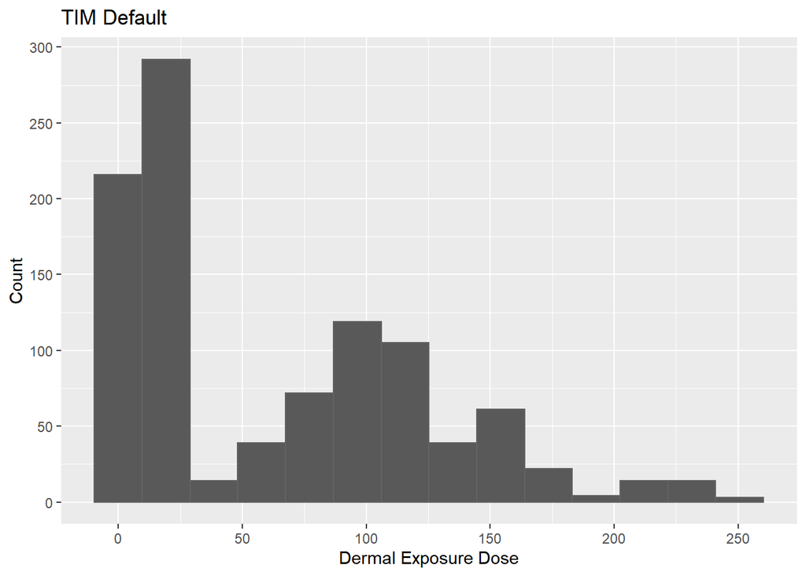

```r
# compute number of histogram bins
bw <- 2*IQR(tim_direct_default) / length(tim_direct_default)^(1/3)

# create frequency histogram
ggplot(combined_data, aes(x=tim_direct_default)) +
  geom_histogram(aes(y = ..count..), color = "#636363", binwidth = bw) +
  scale_x_continuous(name = "Dermal Exposure Dose", breaks = seq(0, 300, 50)) +
  scale_y_continuous(name = "Count", breaks = seq(0, 300, 50)) +
  ggtitle("TIM Default")
```

### **TIM Default Ratios**

Here we compute and visualize the ratio of the TIM Default value to the measured tissue concentrations. A 1:1 ratio signifies perfect agreement between the modeled and measured values.

```r
# Calculate Equation 1b: TIM Default Ratios
combined_data$tim_direct_default_ratios <- combined_data$tim_direct_default/tissue_conc
```

Scatterplots were created to visualize the model’s performance, grouped by variables (study, chemical, application type), respectively. The trend line displays the 1:1 ratio.

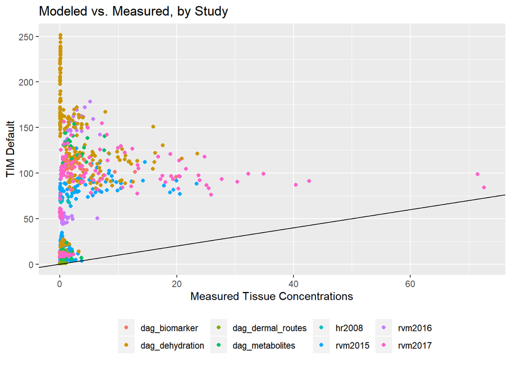

```r
# create scatterplot, categorized by study
ggplot(combined_data, aes(x = tissue_conc, y = tim_direct_default, color = combined_data$source)) +
  geom_point() +
  labs(title = "Modeled vs. Measured, by Study", x = "Measured Tissue Concentrations", y = "TIM Default") +
  geom_abline(intercept = 0, slope = 1) +
  theme(legend.position = "bottom", legend.title = element_blank())
```

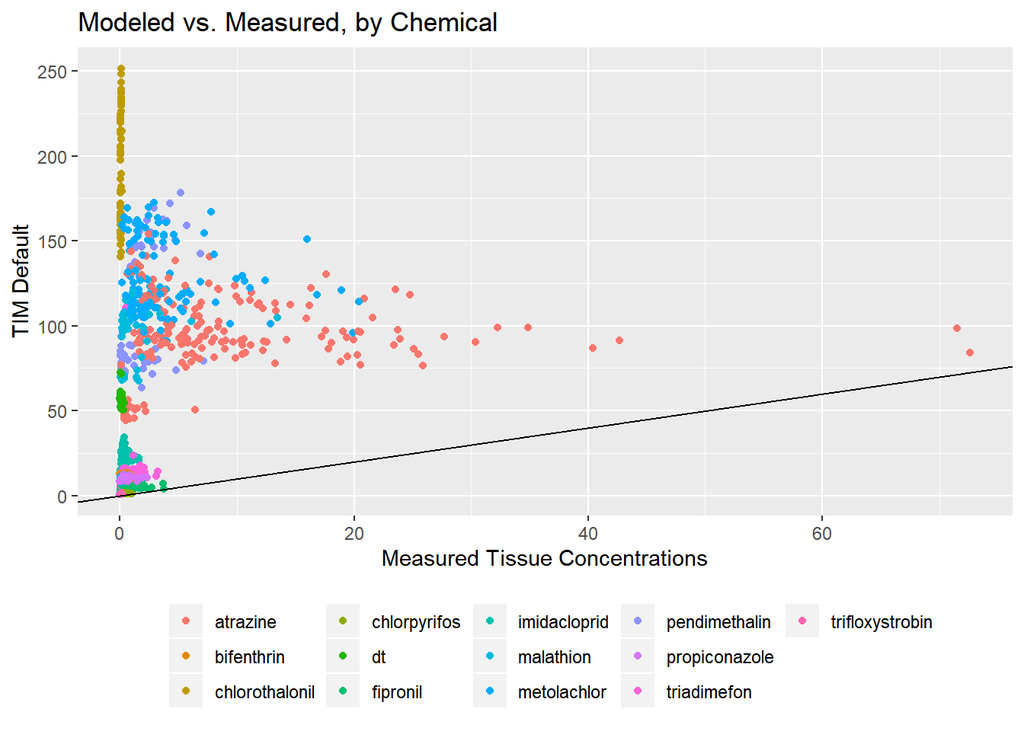

[figure not shown]

```r
# create scatterplot, categorized by chemical
ggplot(combined_data, aes(x = tissue_conc, y = tim_direct_default, color = combined_data$chemical)) +
  geom_point() +
  labs(title = "Modeled vs. Measured, by Chemical", x = "Measured Tissue Concentrations", y = "TIM Default") +
  geom_abline(intercept = 0, slope = 1) +
  theme(legend.position = "bottom", legend.title = element_blank())
```

### **TIM Amphibian Calculation**

To gain a better understanding of pesticide risks on amphibians, the dermal exposure dose was also computed with a modified allometric relationship between body weight and surface area that is better suited for amphibians (Hutchison et al. 1968, EPA 2009).

```r
# Equation 2: TIM Amphibians value (Hutchinson body weight)
sa_amphib_hutchinson <- 1.131 * (body_weight ^ 0.579)
```

```r
# Calculate Equation 2a: TIM Amphibian
combined_data$tim_direct_amphib <- (app_rate * conv_rate * sa_amphib_hutchinson * sa_tim_default_frac * dermal_af)/body_weight

tim_direct_amphib <- combined_data$tim_direct_amphib
```

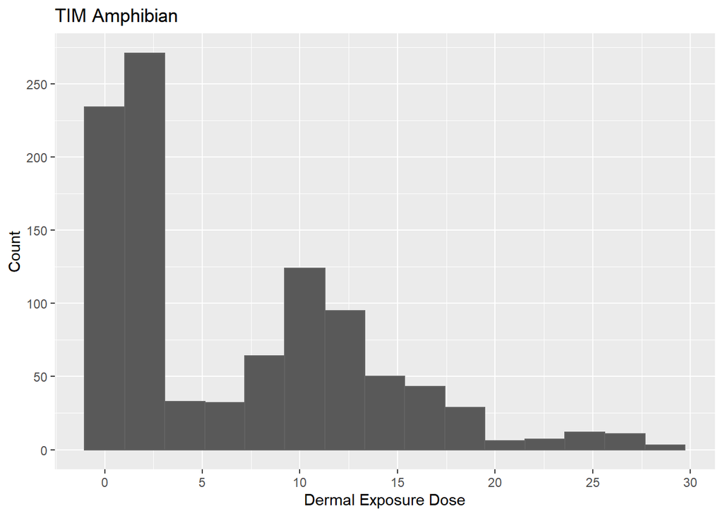

```r
# compute number of bins
bw <- 2*IQR(tim_direct_amphib) / length(tim_direct_amphib)^(1/3)

# create frequency histogram
ggplot(combined_data, aes(x=tim_direct_amphib)) +
  geom_histogram(aes(y = ..count..), color = "#636363", binwidth = bw) +
  scale_x_continuous(name = "Dermal Exposure Dose", breaks = seq(0, 30, 5)) +
  scale_y_continuous(name = "Count", breaks = seq(0, 300, 50)) +
  ggtitle("TIM Amphibian")
```

### **TIM Amphibian Ratios**

Here we compute and visualize the ratio of the TIM Amphibian values to the measured tissue concentrations. A 1:1 ratio signifies perfect agreement between the modeled and measured values.

```r
# Calculate Equation 2b: TIM Amphibian Ratios
combined_data$tim_direct_amphib_ratios <- combined_data$tim_direct_amphib/tissue_conc
```

Scatterplots were created to visualize the model’s performance, grouped by variables (study, chemical, application type), respectively. The trend line displays the 1:1 ratio.

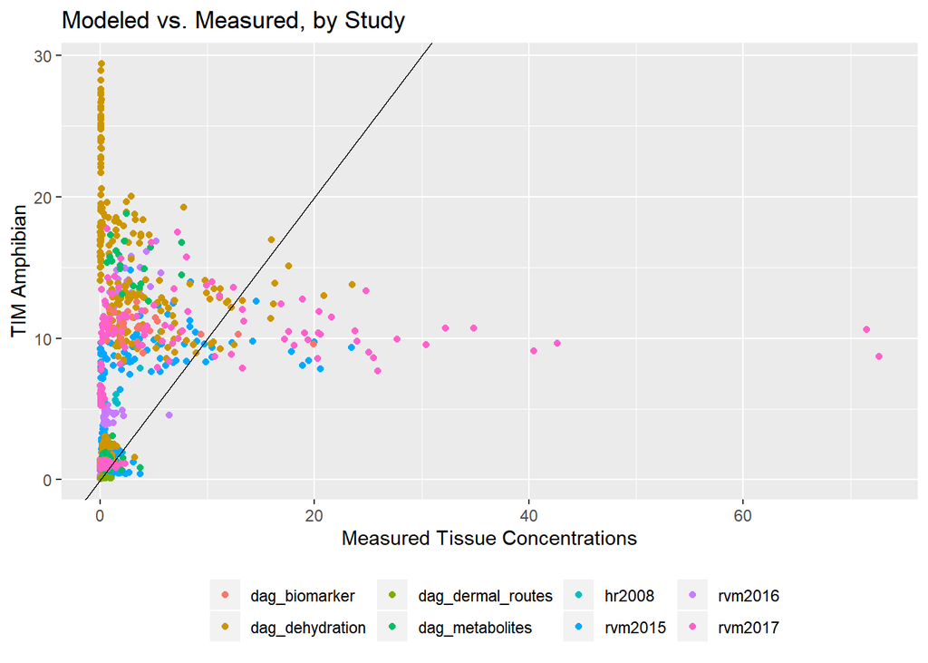

```r
# create scatterplot, categorized by study
ggplot(combined_data, aes(x = tissue_conc, y = tim_direct_amphib, color = combined_data$source)) +
  geom_point() +
  labs(title = "Modeled vs. Measured, by Study", x = "Measured Tissue Concentrations", y = "TIM Amphibian") +
  geom_abline(intercept = 0, slope = 1) +
  theme(legend.position = "bottom", legend.title = element_blank())
```

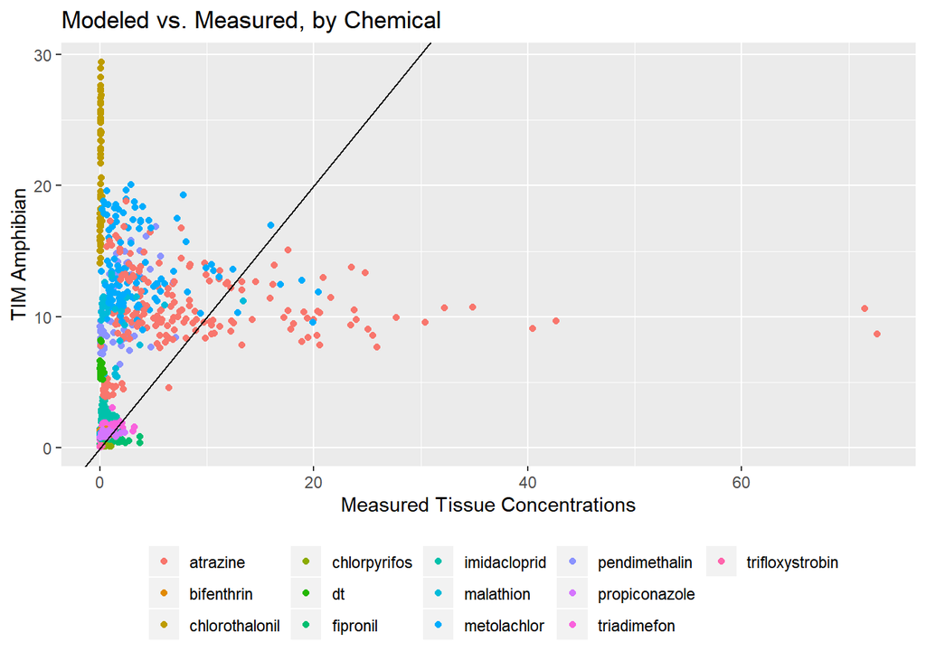

```r
# create scatterplot, categorized by chemical
ggplot(combined_data, aes(x = tissue_conc, y = tim_direct_amphib, color = combined_data$chemical)) +
  geom_point() +
  labs(title = "Modeled vs. Measured, by Chemical", x = "Measured Tissue Concentrations", y = "TIM Amphibian") +
  geom_abline(intercept = 0, slope = 1) +
  theme(legend.position = "bottom", legend.title = element_blank())
```

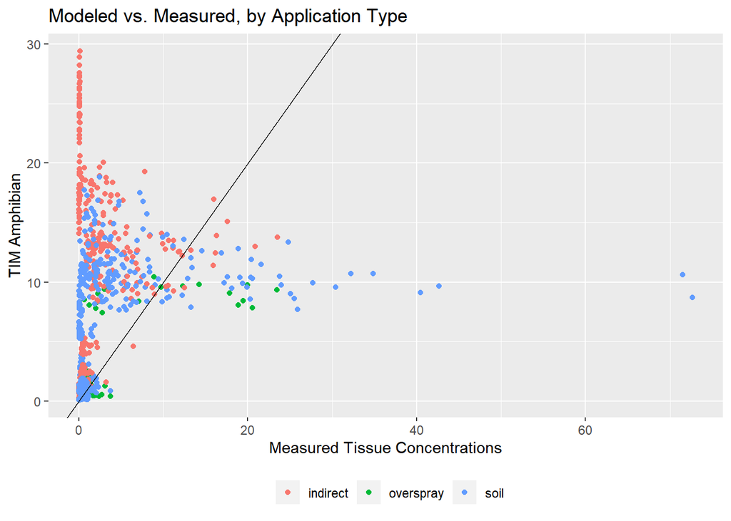

```r
# create scatterplot, categorized by application type
ggplot(combined_data, aes(x = tissue_conc, y = tim_direct_amphib, color = combined_data$application)) +
  geom_point() +
  labs(title = "Modeled vs. Measured, by Application Type", x = "Measured Tissue Concentrations", y = "TIM Amphibian") +
  geom_abline(intercept = 0, slope = 1) +
  theme(legend.position = "bottom", legend.title = element_blank())
```

# **Assessing Model Performance**

The TIM Default and TIM Amphibian models, described and shown above, were compared to one another and to the post-exposure amphibian body burdens found in the collated data set in order to assess model performance.

```r
# Create df of ratios
model_log_ratios <- as.vector(c(log10(combined_data$tim_direct_default_ratios),
                        y=log10(combined_data$tim_direct_amphib_ratios)))
model_factor <- as.vector(c(rep('tim_default_direct',n),rep('tim_amphib_direct',n)))
df.ratios <- data.frame(x=model_factor, y=model_log_ratios)

# Create df of tissue_conc and TIM Amphibian
df.tim_amphib <- data.frame(x=tissue_conc, y=tim_direct_amphib)

# Create df of tissue_conc and TIM Default
df.tim_default <- data.frame(x=tissue_conc, y=tim_direct_default)
```

### **Comparing Models**

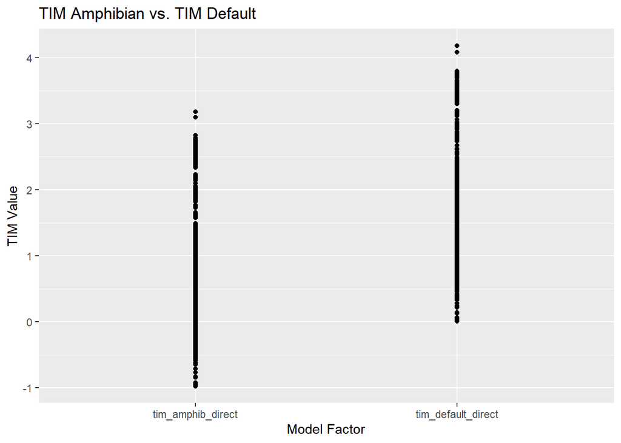

```r
# compare default and amphib ratios
ggplot(df.ratios, aes(x=x, y=y)) +
  geom_point() +
  labs(title="TIM Amphibian vs. TIM Default",  x="Model Factor", y = "TIM Value")
```

### **Plotting Modeled vs. Measured**

Again, scatterplots comparing the modeled vs. measured values are shown, this time setting models side-by-side. A model along the 1:1 line would display perfect agreement with the measured values.

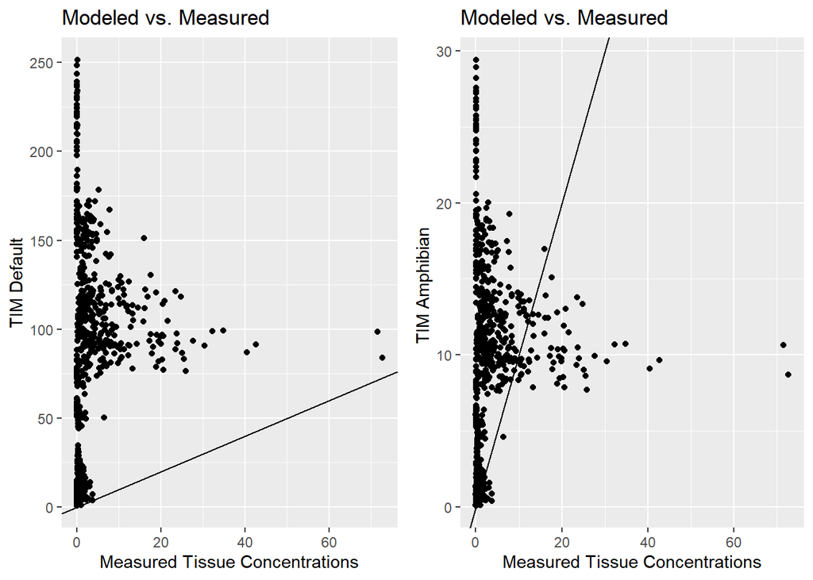

```r
# scatterplot of TIM default values
plot_default <- ggplot(df.tim_default, aes(x=x, y=y)) +
  geom_point() +
  labs(title="Modeled vs. Measured",  x="Measured Tissue Concentrations", y = "TIM Default") +
  geom_abline(intercept = 0, slope = 1)

# scatterplot of TIM amphib values
plot_amphib <- ggplot(df.tim_amphib, aes(x=x, y=y)) +
  geom_point() +
  labs(title="Modeled vs. Measured",  x="Measured Tissue Concentrations", y = "TIM Amphibian ") +
  geom_abline(intercept = 0, slope = 1)

# arrange 1row*2col grid for display
grid.arrange(plot_default, plot_amphib, ncol = 2)
```

### **Plotting log10 Ratio of Modeled Burdens to Observed Burdens**

Box plots were utilized to further assess model performance. Well-performing models would minimize error, and therefore would have a higher percentage of ratios near zero (log10 of unity).

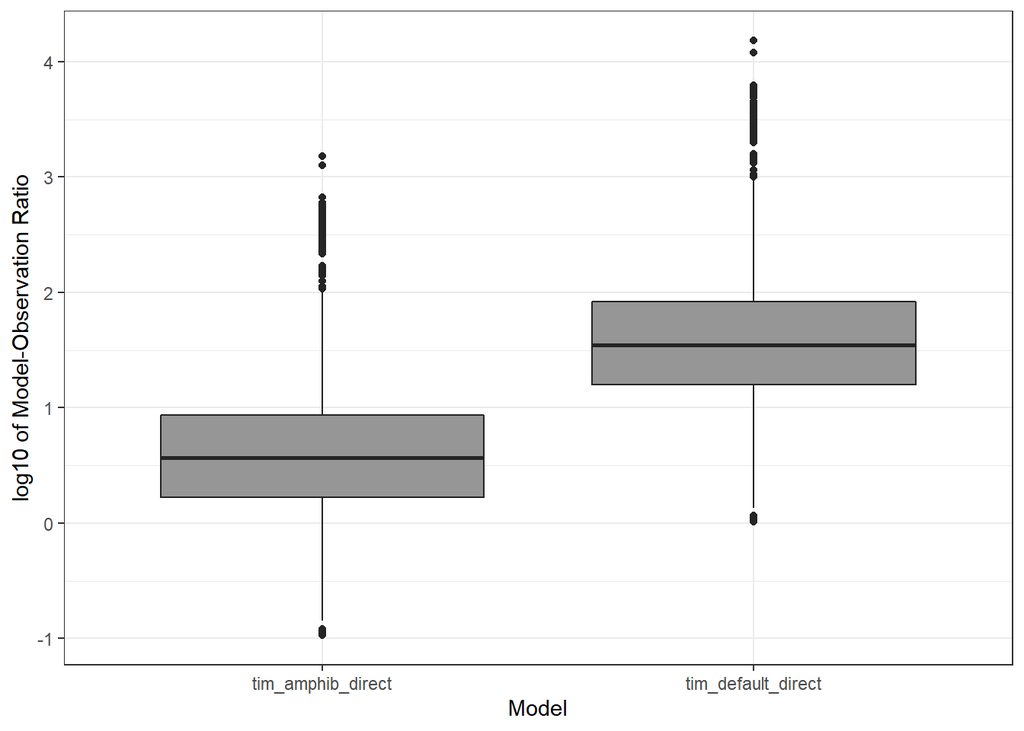

```r
fill <- "#969696"
line <- "#252525"
ggplot(df.ratios, aes(x=x,y=y)) +
    geom_boxplot(fill = fill, colour = line) +
    scale_x_discrete(name = "Model") +
    scale_y_continuous(name = "log10 of Model-Observation Ratio") +
    theme_bw()
```

```r
model_boxplot_filename <- paste(amphibdir_graphics,"model_boxplot.png",sep='')
ggsave(model_boxplot_filename, device="png", width=4, height=4)
```

### **False Negative Rates**

Summary statistics for false negative rates were also computed for both models. False negative rates are defined as an outcome where the modeled value is less than the measured value. This rate is based on a Type II Error in statistical hypothesis testing. False negative rates assess how often a model under-estimates the measurement of interest.

#### **TIM Default**

As displayed below, there are zero false negative rates for TIM Default. But, 134/1014 (13.2%) of the measurements are within an order of magnitude of the modeled value.

```r
# False Negative Rate: TIM Default
sum(tissue_conc > tim_direct_default)
```

```
## [1] 0
```

```r
# False Negative Rate (x10): TIM Default
sum(tissue_conc*10 > tim_direct_default)
```

```
## [1] 134
```

#### **TIM Amphibian**

There are 127/1014 (12.5%) false negative screen results for TIM Amphibian, and 786/1014 (77.5%) measurements within an order of magnitude of the modeled value. TIM Amphibian uses a less conservative but more representative surface area calculation for amphibians.

```r
# False Negative Rate: TIM Amphibian
sum(tissue_conc > tim_direct_amphib)
```

```
## [1] 127
```

```r
# False Negative Rate (x10): TIM Amphibian
sum(tissue_conc*10 > tim_direct_amphib)
```

```
## [1] 786
```

#### **By Study**

False Negative Rates were also computed indiviually by study source. The table below displays the false negative rates and the measurements within an order of magnitude of the modeled value (displayed as %).

|  | sample_size | TIM Default fnr | TIM Default fnr_10 | TIM Amphibian fnr | TIM Amphibian fnr_10 |
| --- | --- | --- | --- | --- | --- |
| Van Meter 2014/15 total | 196 | 0 | 25.00 | 22.45 | 78.06 |
| Van Meter 2014/15 soil | 151 | 0 | 17.22 | 13.91 | 72.85 |
| Van Meter 2014/15 overspray | 45 | 0 | 51.11 | 51.11 | 95.56 |
| Van Meter 2016 | 96 | 0 | 1.04 | 2.08 | 76.04 |
| Van Meter 2018 | 137 | 0 | 26.28 | 26.28 | 64.96 |
| Henson-Ramsey 2008 | 9 | 0 | 0.00 | 0.00 | 55.56 |
| Glinski 2018b (Metabolites) | 60 | 0 | 18.33 | 16.67 | 88.33 |
| Glinski 2018a (Dehydration) | 300 | 0 | 6.00 | 5.00 | 69.33 |
| Glinski 2019 (Biomarkers) | 192 | 0 | 3.65 | 4.17 | 94.27 |
| Glinski 2020 (Dermal) | 24 | 0 | 50.00 | 50.00 | 100.00 |

### **Comparing Surface Area Calculations**

While TIM Amphibian had a higher percentage of false negative screening values than TIM Default, the difference in screening values can be attributed to the surface area calculation. Amphibian surface area, as compared to the TIM Default surface area based on birds, is extrapolated from measured body weights. The comparison between surface area calculations is depicted below.

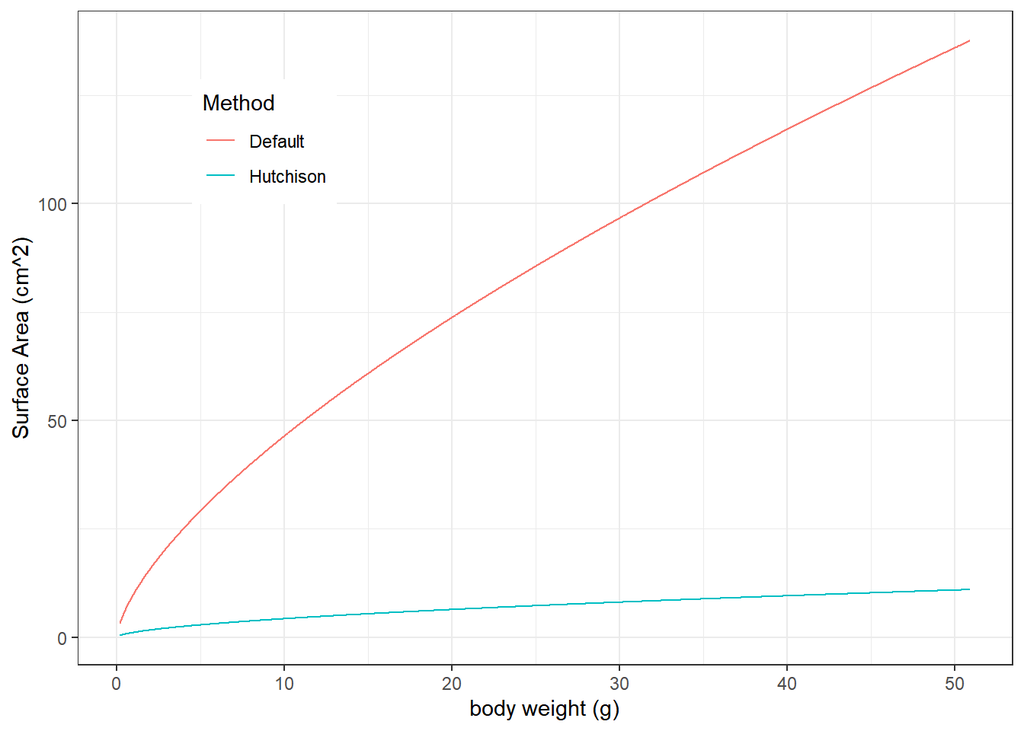

```r
min_bw <- min(combined_data$body_weight_g, na.rm=T)
max_bw <- max(combined_data$body_weight_g, na.rm=T)
range_bw <- seq(min_bw, max_bw, by = 0.01)
default_sa <- 10*range_bw^0.667
hutchison_sa <- 1.131 * range_bw^0.579
#max(default_sa/hutchison_sa)
sa_data <- data.frame(range_bw, default_sa, hutchison_sa)
ggplot(sa_data, aes(range_bw)) +
  labs(x = "body weight (g)", y = "Surface Area (cm^2)",color = "Method") +
  geom_line(aes(y = default_sa, colour = "Default")) +
  geom_line(aes(y = hutchison_sa, colour = "Hutchison")) +
  theme_bw() +
  theme(legend.position =c(0.2,0.8))
```

```r
sa_comparison_filename <- paste(amphibdir_graphics,"sa_comparison.png",sep='')
ggsave(sa_comparison_filename, device="png", width=4, height=4)
```